# CaseStudy2_Thibeaux

Thibeaux

2023-04-10

Presentation: https://youtu.be/h0gjqM3-jDo RShiny App: https://athibeaux.shinyapps.io/attrition-factors/

# Data Cleaning

```r
sum(is.na(fritos))
```

```
## [1] 0
```

```r
fritos$Attrition = as.factor(fritos$Attrition)
fritos$BusinessTravel = as.factor(fritos$BusinessTravel)
fritos$Department = as.factor(fritos$Department)
fritos$EducationField = as.factor(fritos$EducationField)
fritos$Gender = as.factor(fritos$Gender)
fritos$JobRole = as.factor(fritos$JobRole)
fritos$MaritalStatus = as.factor(fritos$MaritalStatus)
fritos$Over18 = as.factor(fritos$Over18)
fritos$OverTime = as.factor(fritos$OverTime)

summary(fritos)
```

```
##        ID             Age        Attrition           BusinessTravel
##  Min.   :  1.0   Min.   :18.00   No :730   Non-Travel       : 94
##  1st Qu.:218.2   1st Qu.:30.00   Yes:140   Travel_Frequently:158
##  Median :435.5   Median :35.00             Travel_Rarely    :618
##  Mean   :435.5   Mean   :36.83
##  3rd Qu.:652.8   3rd Qu.:43.00
##  Max.   :870.0   Max.   :60.00
##
##    DailyRate                       Department  DistanceFromHome   Education
##  Min.   : 103.0   Human Resources       : 35   Min.   : 1.000   Min.   :1.000
##  1st Qu.: 472.5   Research & Development:562   1st Qu.: 2.000   1st Qu.:2.000
##  Median : 817.5   Sales                 :273   Median : 7.000   Median :3.000
##  Mean   : 815.2                                Mean   : 9.339   Mean   :2.901
##  3rd Qu.:1165.8                                3rd Qu.:14.000   3rd Qu.:4.000
##  Max.   :1499.0                                Max.   :29.000   Max.   :5.000
##
##           EducationField EmployeeCount EmployeeNumber   EnvironmentSatisfaction
##  Human Resources : 15    Min.   :1     Min.   :   1.0   Min.   :1.000
##  Life Sciences   :358    1st Qu.:1     1st Qu.: 477.2   1st Qu.:2.000
##  Marketing       :100    Median :1     Median :1039.0   Median :3.000
##  Medical         :270    Mean   :1     Mean   :1029.8   Mean   :2.701
##  Other           : 52    3rd Qu.:1     3rd Qu.:1561.5   3rd Qu.:4.000
##  Technical Degree: 75    Max.   :1     Max.   :2064.0   Max.   :4.000
##
##     Gender      HourlyRate     JobInvolvement     JobLevel
##  Female:354   Min.   : 30.00   Min.   :1.000   Min.   :1.000
##  Male  :516   1st Qu.: 48.00   1st Qu.:2.000   1st Qu.:1.000
##               Median : 66.00   Median :3.000   Median :2.000
##               Mean   : 65.61   Mean   :2.723   Mean   :2.039
##               3rd Qu.: 83.00   3rd Qu.:3.000   3rd Qu.:3.000
##               Max.   :100.00   Max.   :4.000   Max.   :5.000
##
##                       JobRole    JobSatisfaction  MaritalStatus MonthlyIncome
##  Sales Executive          :200   Min.   :1.000   Divorced:191   Min.   : 1081
##  Research Scientist       :172   1st Qu.:2.000   Married :410   1st Qu.: 2840
##  Laboratory Technician    :153   Median :3.000   Single  :269   Median : 4946
##  Manufacturing Director   : 87   Mean   :2.709                  Mean   : 6390
##  Healthcare Representative: 76   3rd Qu.:4.000                  3rd Qu.: 8182
##  Sales Representative     : 53   Max.   :4.000                  Max.   :19999
##  (Other)                  :129
```

[output cut: 17 more lines]

```
##  Min.   : 0.00     Min.   :0.000         Min.   :1.000   Min.   : 0.000
##  1st Qu.: 6.00     1st Qu.:2.000         1st Qu.:2.000   1st Qu.: 3.000
##  Median :10.00     Median :3.000         Median :3.000   Median : 5.000
##  Mean   :11.05     Mean   :2.832         Mean   :2.782   Mean   : 6.962
##  3rd Qu.:15.00     3rd Qu.:3.000         3rd Qu.:3.000   3rd Qu.:10.000
##  Max.   :40.00     Max.   :6.000         Max.   :4.000   Max.   :40.000
##
##  YearsInCurrentRole YearsSinceLastPromotion YearsWithCurrManager
##  Min.   : 0.000     Min.   : 0.000          Min.   : 0.00
##  1st Qu.: 2.000     1st Qu.: 0.000          1st Qu.: 2.00
##  Median : 3.000     Median : 1.000          Median : 3.00
##  Mean   : 4.205     Mean   : 2.169          Mean   : 4.14
##  3rd Qu.: 7.000     3rd Qu.: 3.000          3rd Qu.: 7.00
##  Max.   :18.000     Max.   :15.000          Max.   :17.00
##
```

# Data Balancing

I learned about ROSE package and used it successfully from this helpful website: https://www.analyticsvidhya.com/blog/2016/03/practical-guide-deal-imbalanced-classification-problems/

```r
set.seed(9)
splitPerc = .8
trainIndices = sample(1:dim(fritos)[1],round(splitPerc * dim(fritos)[1]))
train = fritos[trainIndices,]
test = fritos[-trainIndices,]

# Using rpart library
treeimb <- rpart(Attrition ~ ., data = train)
pred.treeimb <- predict(treeimb, newdata = test)

# Check classes
table(train$Attrition)
```

```
##
##  No Yes
## 585 111
```

```r
# Check classes distribution
prop.table(table(train$Attrition))
```

```
##
##        No       Yes
## 0.8405172 0.1594828
```

```r
# Use ROSE library functions accuracy.meas and roc.curve to look at baseline measures
accuracy.meas(test$Attrition, pred.treeimb[,2])
```

```
##
## Call:
## accuracy.meas(response = test$Attrition, predicted = pred.treeimb[,
##     2])
##
## Examples are labelled as positive when predicted is greater than 0.5
##
## precision: 0.600
## recall: 0.207
## F: 0.154
```

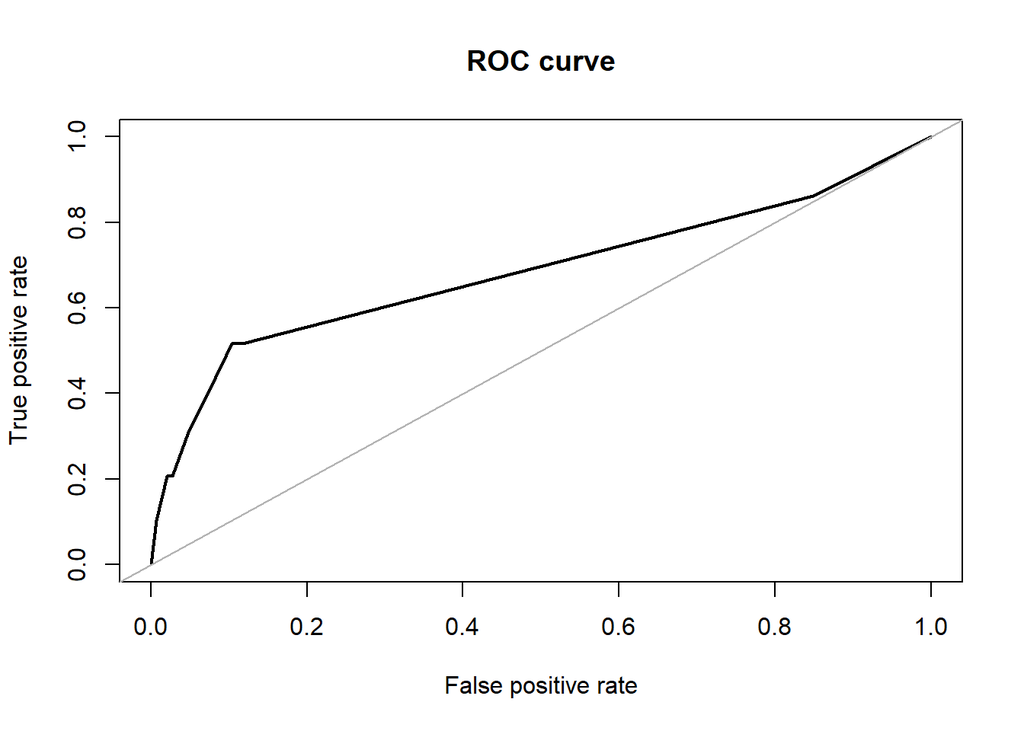

```
## Area under the curve (AUC): 0.685
```

```r
roc.curve(test$Attrition, pred.treeimb[,2])
```

```r
# Over sampling
ov_goal = sum(train$Attrition == "No")*2
data_balanced_over <- ovun.sample(Attrition ~ ., data = train, method = "over",N = ov_goal)$data
table(data_balanced_over$Attrition)
```

```
##
##  No Yes
## 585 585
```

```r
# Under sampling
un_goal = sum(train$Attrition == "Yes")*2
data_balanced_under <- ovun.sample(Attrition ~ ., data = train, method = "under", N = un_goal, seed = 1)$data
table(data_balanced_under$Attrition)
```

```
##
##  No Yes
## 111 111
```

```r
# Both (Oversample Minority class with replacement, Undersample majority class without replacement)
total = dim(train)[1]*1
data_balanced_both <- ovun.sample(Attrition ~ ., data = train, method = "both", p=0.5,N=total, seed = 1)$data
table(data_balanced_both$Attrition)
```

```
##
##  No Yes
## 358 338
```

```r
# ROSE method - incorporates synthetic data
data.rose <- ROSE(Attrition ~ ., data = train, seed = 1)$data
table(data.rose$Attrition)
```

```
##
##  No Yes
## 358 338
```

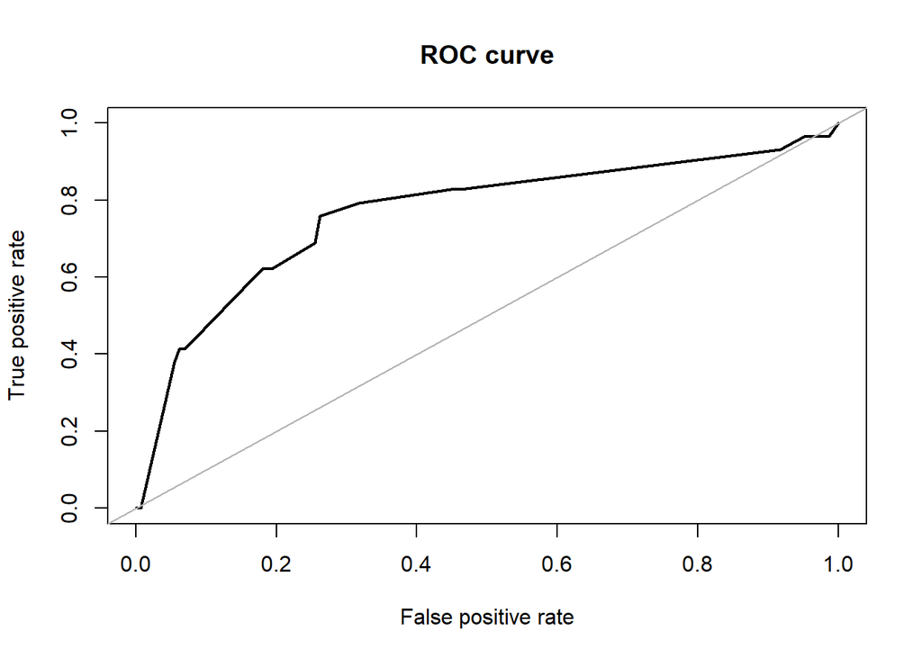

```
## Area under the curve (AUC): 0.766
```

```r
# Build decision tree models
tree.rose <- rpart(Attrition ~ ., data = data.rose)
tree.over <- rpart(Attrition ~ ., data = data_balanced_over)
tree.under <- rpart(Attrition ~ ., data = data_balanced_under)
tree.both <- rpart(Attrition ~ ., data = data_balanced_both)

#make predictions on unseen data
pred.tree.rose <- predict(tree.rose, newdata = test)
pred.tree.over <- predict(tree.over, newdata = test)
pred.tree.under <- predict(tree.under, newdata = test)
pred.tree.both <- predict(tree.both, newdata = test)

#AUC ROSE
roc.curve(test$Attrition, pred.tree.rose[,2])
```

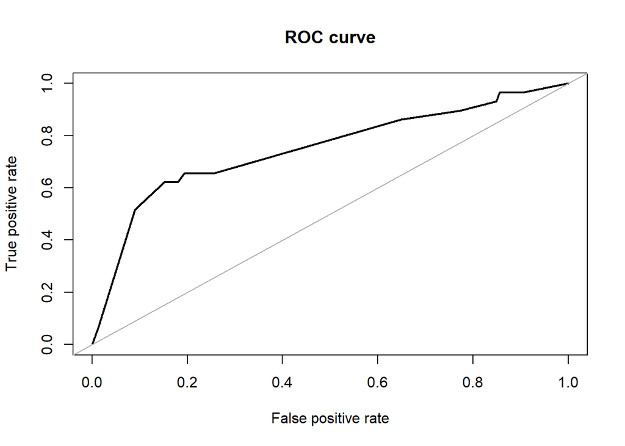

```
## Area under the curve (AUC): 0.749
```

```r
#AUC Oversampling
roc.curve(test$Attrition, pred.tree.over[,2])
```

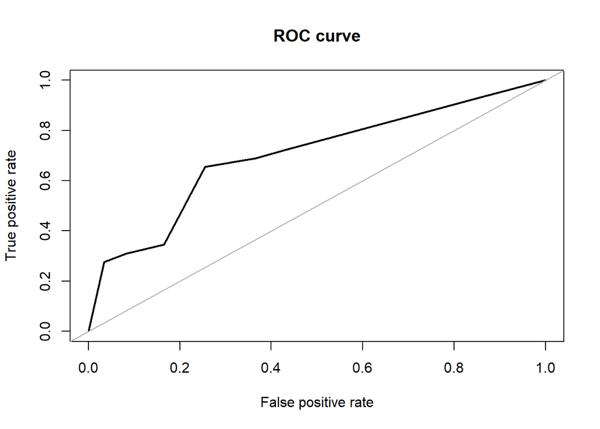

```
## Area under the curve (AUC): 0.702
```

```r
#AUC Undersampling
roc.curve(test$Attrition, pred.tree.under[,2])
```

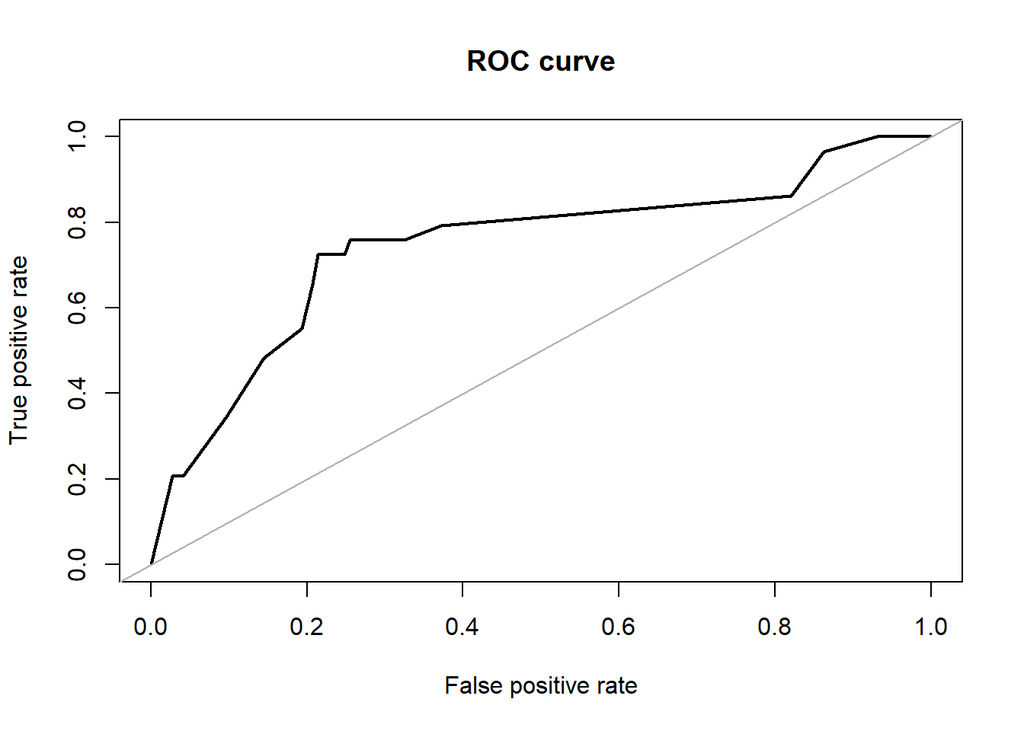

```
## Area under the curve (AUC): 0.744
```

```r
#AUC Both
roc.curve(test$Attrition, pred.tree.both[,2])
```

```r
# Check the model accuracy using holdout and bagging method
ROSE.holdout <- ROSE.eval(Attrition ~ ., data = train, learner = rpart, method.assess = "holdout", extr.pred = function(obj)obj[,2], seed = 1)
ROSE.holdout
```

```
##
## Call:
## ROSE.eval(formula = Attrition ~ ., data = train, learner = rpart,
##     extr.pred = function(obj) obj[, 2], method.assess = "holdout",
##     seed = 1)
##
## Holdout estimate of auc: 0.820
```

Since there is not a big improvement between the AOC in the baseline vs. balancing methods, and the highest AOC is not consistent across seeds, we’ll go with the combination of oversampling and undersampling. I did try the ROSE method but the synthetic data it created was not ideal - such as the new minimum age was 4. Since hopefully FritoLay does not employ 4 year olds, let’d just stick with the data we know.

```r
# Both (Oversample Minority class with replacement, Undersample majority class without replacement)
total = dim(fritos)[1]*1
data_balanced_both <- ovun.sample(Attrition ~ ., data = fritos, method = "both", p=0.5,N=total, seed = 1)$data
table(data_balanced_both$Attrition)
```

```
##
##  No Yes
## 448 422
```

# Exploratory Data Analysis

```r
# Let's look at just the continuous variables
eda.cont = data_balanced_both %>% select(Attrition,Age,DailyRate,DistanceFromHome,Education,EnvironmentSatisfaction,HourlyRate,JobInvolvement,JobLevel,JobSatisfaction,MonthlyIncome,MonthlyRate,NumCompaniesWorked,PercentSalaryHike,PerformanceRating,RelationshipSatisfaction,StockOptionLevel,TotalWorkingYears,TrainingTimesLastYear,WorkLifeBalance,YearsAtCompany,YearsInCurrentRole,YearsSinceLastPromotion,YearsWithCurrManager)

table(eda.cont$Attrition)
```

```
##
##  No Yes
## 448 422
```

```r
tstt <- function(var1) {
  return(t.test(var1~Attrition, data = eda.cont,conf.level = .95,var.equal=FALSE))
}
tstt(eda.cont$Age)
```

```
##
##  Welch Two Sample t-test
##
## data:  var1 by Attrition
## t = 5.0854, df = 840.48, p-value = 4.526e-07
## alternative hypothesis: true difference in means between group No and group Yes is not equal to 0
## 95 percent confidence interval:
##  1.936672 4.371385
## sample estimates:
##  mean in group No mean in group Yes
##          37.00000          33.84597
```

```r
tstt(eda.cont$DailyRate)
```

```
##
##  Welch Two Sample t-test
##
## data:  var1 by Attrition
## t = 1.0163, df = 859.06, p-value = 0.3098
## alternative hypothesis: true difference in means between group No and group Yes is not equal to 0
## 95 percent confidence interval:
##  -25.47461  80.18306
## sample estimates:
##  mean in group No mean in group Yes
##          794.8661          767.5118
```

```r
tstt(eda.cont$DistanceFromHome)
```

```
##
##  Welch Two Sample t-test
##
## data:  var1 by Attrition
## t = -4.9123, df = 825.14, p-value = 1.085e-06
## alternative hypothesis: true difference in means between group No and group Yes is not equal to 0
## 95 percent confidence interval:
##  -3.860828 -1.656310
## sample estimates:
##  mean in group No mean in group Yes
##          8.504464         11.263033
```

```r
tstt(eda.cont$Education)
```

```
##
##  Welch Two Sample t-test
##
## data:  var1 by Attrition
## t = 1.3923, df = 867.72, p-value = 0.1642
## alternative hypothesis: true difference in means between group No and group Yes is not equal to 0
## 95 percent confidence interval:
##  -0.03989027  0.23462622
## sample estimates:
##  mean in group No mean in group Yes
##          2.919643          2.822275
```

```r
tstt(eda.cont$EnvironmentSatisfaction)
```

```
##
##  Welch Two Sample t-test
##
## data:  var1 by Attrition
## t = 3.0584, df = 832.73, p-value = 0.002297
## alternative hypothesis: true difference in means between group No and group Yes is not equal to 0
## 95 percent confidence interval:
##  0.08391967 0.38461875
## sample estimates:
##  mean in group No mean in group Yes
##          2.774554          2.540284
```

```r
tstt(eda.cont$HourlyRate)
```

```
##
##  Welch Two Sample t-test
##
## data:  var1 by Attrition
## t = -2.0668, df = 867.89, p-value = 0.03905
## alternative hypothesis: true difference in means between group No and group Yes is not equal to 0
## 95 percent confidence interval:
##  -5.5597830 -0.1436699
## sample estimates:
##  mean in group No mean in group Yes
##          65.28571          68.13744
```

```r
tstt(eda.cont$JobInvolvement)
```

```
##
##  Welch Two Sample t-test
##
## data:  var1 by Attrition
## t = 7.6284, df = 806.11, p-value = 6.705e-14
## alternative hypothesis: true difference in means between group No and group Yes is not equal to 0
## 95 percent confidence interval:
##  0.2863155 0.4847153
## sample estimates:
##  mean in group No mean in group Yes
##          2.781250          2.395735
```

```r
tstt(eda.cont$JobLevel)
```

```
##
##  Welch Two Sample t-test
##
## data:  var1 by Attrition
## t = 4.2237, df = 863.19, p-value = 2.659e-05
## alternative hypothesis: true difference in means between group No and group Yes is not equal to 0
## 95 percent confidence interval:
##  0.1561893 0.4273626
## sample estimates:
##  mean in group No mean in group Yes
##          2.033482          1.741706
```

```r
tstt(eda.cont$JobSatisfaction)
```

```
##
##  Welch Two Sample t-test
##
## data:  var1 by Attrition
## t = 2.4431, df = 866.8, p-value = 0.01476
## alternative hypothesis: true difference in means between group No and group Yes is not equal to 0
## 95 percent confidence interval:
##  0.0375003 0.3439528
## sample estimates:
##  mean in group No mean in group Yes
##          2.712054          2.521327
```

```r
tstt(eda.cont$MonthlyIncome)
```

```
##
##  Welch Two Sample t-test
##
## data:  var1 by Attrition
## t = 4.585, df = 867.48, p-value = 5.206e-06
## alternative hypothesis: true difference in means between group No and group Yes is not equal to 0
## 95 percent confidence interval:
##   743.5817 1856.6558
## sample estimates:
##  mean in group No mean in group Yes
##          6377.150          5077.031
```

```r
tstt(eda.cont$MonthlyRate)
```

```
##
##  Welch Two Sample t-test
##
## data:  var1 by Attrition
## t = 1.2225, df = 857.21, p-value = 0.2219
## alternative hypothesis: true difference in means between group No and group Yes is not equal to 0
## 95 percent confidence interval:
##  -361.619 1555.944
## sample estimates:
##  mean in group No mean in group Yes
##          14710.13          14112.97
```

```r
tstt(eda.cont$NumCompaniesWorked)
```

```
##
##  Welch Two Sample t-test
##
## data:  var1 by Attrition
## t = -2.9764, df = 840.16, p-value = 0.003
## alternative hypothesis: true difference in means between group No and group Yes is not equal to 0
## 95 percent confidence interval:
##  -0.8494407 -0.1743194
## sample estimates:
##  mean in group No mean in group Yes
##          2.462054          2.973934
```

```r
tstt(eda.cont$PercentSalaryHike)
```

```
##
##  Welch Two Sample t-test
##
## data:  var1 by Attrition
## t = 0.49405, df = 852.06, p-value = 0.6214
## alternative hypothesis: true difference in means between group No and group Yes is not equal to 0
## 95 percent confidence interval:
##  -0.3864375  0.6464239
## sample estimates:
##  mean in group No mean in group Yes
##          15.42857          15.29858
```

```r
tstt(eda.cont$PerformanceRating)
```

```
##
##  Welch Two Sample t-test
##
## data:  var1 by Attrition
## t = -0.32143, df = 862.71, p-value = 0.748
## alternative hypothesis: true difference in means between group No and group Yes is not equal to 0
## 95 percent confidence interval:
##  -0.05938843  0.04267381
## sample estimates:
##  mean in group No mean in group Yes
##          3.174107          3.182464
```

```r
tstt(eda.cont$RelationshipSatisfaction)
```

```
##
##  Welch Two Sample t-test
##
## data:  var1 by Attrition
## t = 0.31275, df = 856.04, p-value = 0.7545
## alternative hypothesis: true difference in means between group No and group Yes is not equal to 0
## 95 percent confidence interval:
##  -0.1269716  0.1751055
## sample estimates:
##  mean in group No mean in group Yes
##          2.609375          2.585308
```

```r
tstt(eda.cont$StockOptionLevel)
```

```
##
##  Welch Two Sample t-test
##
## data:  var1 by Attrition
## t = 4.4992, df = 849.6, p-value = 7.768e-06
## alternative hypothesis: true difference in means between group No and group Yes is not equal to 0
## 95 percent confidence interval:
##  0.1525929 0.3887493
## sample estimates:
##  mean in group No mean in group Yes
##         0.7991071         0.5284360
```

```r
tstt(eda.cont$TotalWorkingYears)
```

```
##
##  Welch Two Sample t-test
##
## data:  var1 by Attrition
## t = 4.9777, df = 862.54, p-value = 7.771e-07
## alternative hypothesis: true difference in means between group No and group Yes is not equal to 0
## 95 percent confidence interval:
##  1.471093 3.386452
## sample estimates:
##  mean in group No mean in group Yes
##          11.00223           8.57346
```

```r
tstt(eda.cont$TrainingTimesLastYear)
```

```
##
##  Welch Two Sample t-test
##
## data:  var1 by Attrition
## t = 2.6186, df = 868, p-value = 0.008984
## alternative hypothesis: true difference in means between group No and group Yes is not equal to 0
## 95 percent confidence interval:
##  0.05415044 0.37825055
## sample estimates:
##  mean in group No mean in group Yes
##          2.837054          2.620853
```

```r
tstt(eda.cont$WorkLifeBalance)
```

```
##
##  Welch Two Sample t-test
##
## data:  var1 by Attrition
## t = 4.0839, df = 836.63, p-value = 4.854e-05
## alternative hypothesis: true difference in means between group No and group Yes is not equal to 0
## 95 percent confidence interval:
##  0.1083124 0.3087704
## sample estimates:
##  mean in group No mean in group Yes
##          2.845982          2.637441
```

```r
tstt(eda.cont$YearsAtCompany)
```

```
##
##  Welch Two Sample t-test
##
## data:  var1 by Attrition
## t = 3.0967, df = 805.86, p-value = 0.002024
## alternative hypothesis: true difference in means between group No and group Yes is not equal to 0
## 95 percent confidence interval:
##  0.4543821 2.0276550
## sample estimates:
##  mean in group No mean in group Yes
##          7.011161          5.770142
```

```r
tstt(eda.cont$YearsInCurrentRole)
```

```
##
##  Welch Two Sample t-test
##
## data:  var1 by Attrition
## t = 5.3815, df = 867.82, p-value = 9.507e-08
## alternative hypothesis: true difference in means between group No and group Yes is not equal to 0
## 95 percent confidence interval:
##  0.7740586 1.6628067
## sample estimates:
##  mean in group No mean in group Yes
##          4.339286          3.120853
```

```r
tstt(eda.cont$YearsSinceLastPromotion)
```

```
##
##  Welch Two Sample t-test
##
## data:  var1 by Attrition
## t = -1.4953, df = 840.02, p-value = 0.1352
## alternative hypothesis: true difference in means between group No and group Yes is not equal to 0
## 95 percent confidence interval:
##  -0.7726361  0.1044531
## sample estimates:
##  mean in group No mean in group Yes
##          2.037946          2.372038
```

```r
tstt(eda.cont$YearsWithCurrManager)
```

```
##
##  Welch Two Sample t-test
##
## data:  var1 by Attrition
## t = 4.8737, df = 868, p-value = 1.302e-06
## alternative hypothesis: true difference in means between group No and group Yes is not equal to 0
## 95 percent confidence interval:
##  0.6648168 1.5613172
## sample estimates:
##  mean in group No mean in group Yes
##          4.357143          3.244076
```

Here is a further summary of the significant T-Tests Not sufficient Evidence: Relationship Satisfacation: 0.7545 Performance Rating: 0.748 Percent Salary Hike: 0.6214 Daily Rate: 0.3098 Monthly Rate: 0.2219 Education: 0.1642 Years Since Last Promotion: 0.1352

Sufficient Evidence: Years at Company: 0.002024 Environmental Satisfaction: 0.002297 Number of Companies Worked: 0.003 Training Times Last Year: 0.008984 Job Satisfaction: 0.01476 Hourly Rate: 0.03905

Strong Evidence: Job Level: 2.659e-05 Distance from Home: 1.085e-06 Years with Current Manager: 1.302e-06 Work Life Balance: 4.854e-05 Monthly Income: 5.206e-06 Stock Option Level: 7.768e-06 Age: 4.526e-07 Total Working Years: 7.771e-07 Years in Current Role: 9.507e-08

Overwhelming Evidence: Job Involvement: 6.705e-14

```r
eda.pvalues = eda.cont %>% select(Attrition,Age,DistanceFromHome,EnvironmentSatisfaction,HourlyRate,JobInvolvement,JobLevel,JobSatisfaction,MonthlyIncome,NumCompaniesWorked,StockOptionLevel,TotalWorkingYears,TrainingTimesLastYear,WorkLifeBalance,YearsAtCompany,YearsInCurrentRole,YearsWithCurrManager)

summary(eda.pvalues)
```

```
##  Attrition      Age        DistanceFromHome EnvironmentSatisfaction
##  No :448   Min.   :18.00   Min.   : 1.000   Min.   :1.000
##  Yes:422   1st Qu.:29.00   1st Qu.: 2.000   1st Qu.:2.000
##            Median :34.00   Median : 7.500   Median :3.000
##            Mean   :35.47   Mean   : 9.843   Mean   :2.661
##            3rd Qu.:41.00   3rd Qu.:16.000   3rd Qu.:4.000
##            Max.   :60.00   Max.   :29.000   Max.   :4.000
##    HourlyRate     JobInvolvement     JobLevel     JobSatisfaction
##  Min.   : 30.00   Min.   :1.000   Min.   :1.000   Min.   :1.00
##  1st Qu.: 49.00   1st Qu.:2.000   1st Qu.:1.000   1st Qu.:2.00
##  Median : 68.00   Median :3.000   Median :2.000   Median :3.00
##  Mean   : 66.67   Mean   :2.594   Mean   :1.892   Mean   :2.62
##  3rd Qu.: 84.00   3rd Qu.:3.000   3rd Qu.:2.000   3rd Qu.:4.00
##  Max.   :100.00   Max.   :4.000   Max.   :5.000   Max.   :4.00
##  MonthlyIncome   NumCompaniesWorked StockOptionLevel TotalWorkingYears
##  Min.   : 1081   Min.   :0.00       Min.   :0.0000   Min.   : 0.000
##  1st Qu.: 2562   1st Qu.:1.00       1st Qu.:0.0000   1st Qu.: 5.000
##  Median : 4559   Median :1.00       Median :0.0000   Median : 9.000
##  Mean   : 5747   Mean   :2.71       Mean   :0.6678   Mean   : 9.824
##  3rd Qu.: 6866   3rd Qu.:4.00       3rd Qu.:1.0000   3rd Qu.:13.000
##  Max.   :19943   Max.   :9.00       Max.   :3.0000   Max.   :40.000
##  TrainingTimesLastYear WorkLifeBalance YearsAtCompany   YearsInCurrentRole
##  Min.   :0.000         Min.   :1.000   Min.   : 0.000   Min.   : 0.000
##  1st Qu.:2.000         1st Qu.:2.000   1st Qu.: 2.000   1st Qu.: 1.000
##  Median :3.000         Median :3.000   Median : 5.000   Median : 2.000
##  Mean   :2.732         Mean   :2.745   Mean   : 6.409   Mean   : 3.748
##  3rd Qu.:3.000         3rd Qu.:3.000   3rd Qu.: 9.000   3rd Qu.: 7.000
##  Max.   :6.000         Max.   :4.000   Max.   :40.000   Max.   :16.000
##  YearsWithCurrManager
##  Min.   : 0.000
##  1st Qu.: 1.000
##  Median : 3.000
##  Mean   : 3.817
##  3rd Qu.: 7.000
##  Max.   :17.000
```

Since the most significant single factor for attrition rate is Job Involvement, we will start our model exploration there.

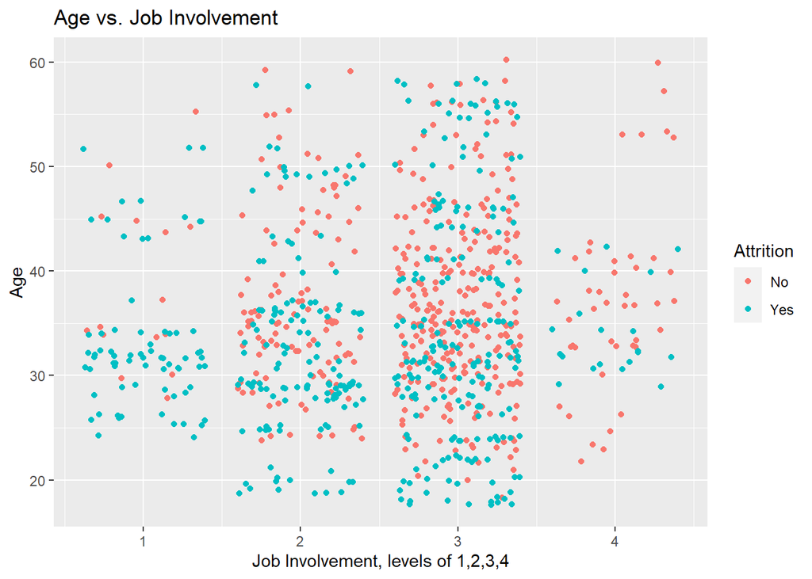

```r
# Raw Data
data_balanced_both %>% ggplot(aes(JobInvolvement, Age, color = Attrition)) +
  geom_jitter() +
  ylab("Age") + xlab("Job Involvement, levels of 1,2,3,4") +
  ggtitle("Age vs. Job Involvement")
```

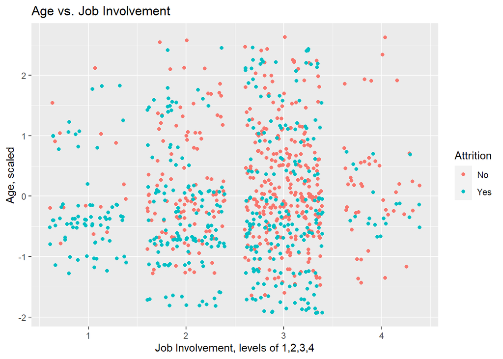

```r
data_balanced_both$Z_Age = scale(data_balanced_both$Age)

# Scaled Data
data_balanced_both %>% ggplot(aes(JobInvolvement,Z_Age, color = Attrition)) +
  geom_jitter() +
  ylab("Age, scaled") + xlab("Job Involvement, levels of 1,2,3,4") +
  ggtitle("Age vs. Job Involvement")
```

```r
# Split our data into a train and test set
splitPerc = .8
trainIndices = sample(1:dim(data_balanced_both)[1],round(splitPerc * dim(data_balanced_both)[1]))
dftrain = data_balanced_both[trainIndices,]
dftest = data_balanced_both[-trainIndices,]

# k = 3 for raw data
classifications = knn(dftrain[,c(2,15)],dftest[,c(2,15)],dftrain$Attrition,
                      prob = TRUE, k = 3)
table(classifications,dftest$Attrition)
```

```
##
## classifications No Yes
##             No  52  27
##             Yes 32  63
```

```r
confusionMatrix(table(classifications,dftest$Attrition))
```

```
## Confusion Matrix and Statistics
##
##
## classifications No Yes
##             No  52  27
##             Yes 32  63
##
##                Accuracy : 0.6609
##                  95% CI : (0.5854, 0.7308)
##     No Information Rate : 0.5172
##     P-Value [Acc > NIR] : 8.766e-05
##
##                   Kappa : 0.3197
##
##  Mcnemar's Test P-Value : 0.6025
##
##             Sensitivity : 0.6190
##             Specificity : 0.7000
##          Pos Pred Value : 0.6582
##          Neg Pred Value : 0.6632
##              Prevalence : 0.4828
##          Detection Rate : 0.2989
##    Detection Prevalence : 0.4540
##       Balanced Accuracy : 0.6595
##
##        'Positive' Class : No
##
```

```r
# k = 3 for standardized data
classifications = knn(dftrain[,c(2,37)],dftest[,c(2,37)],dftrain$Attrition,
                      prob = TRUE, k = 3)
table(classifications,dftest$Attrition)
```

```
##
## classifications No Yes
##             No  59  35
##             Yes 25  55
```

```r
confusionMatrix(table(classifications,dftest$Attrition))
```

```
## Confusion Matrix and Statistics
##
##
## classifications No Yes
##             No  59  35
##             Yes 25  55
##
##                Accuracy : 0.6552
##                  95% CI : (0.5795, 0.7255)
##     No Information Rate : 0.5172
##     P-Value [Acc > NIR] : 0.0001613
##
##                   Kappa : 0.3123
##
##  Mcnemar's Test P-Value : 0.2452781
##
##             Sensitivity : 0.7024
##             Specificity : 0.6111
##          Pos Pred Value : 0.6277
##          Neg Pred Value : 0.6875
##              Prevalence : 0.4828
##          Detection Rate : 0.3391
##    Detection Prevalence : 0.5402
##       Balanced Accuracy : 0.6567
##
##        'Positive' Class : No
##
```

We have already met our 60% threshhold for Sensitivity and Specificity - but let’s see if a different k would get those higher.

Let’s run a Cross Validation on the model:

```r
#Internal CV
classifications = knn.cv(data_balanced_both[,c(2,15)],data_balanced_both$Attrition,prob = TRUE, k = 3)
confusionMatrix(table(classifications,data_balanced_both$Attrition))
```

```
## Confusion Matrix and Statistics
##
##
## classifications  No Yes
##             No  311 132
##             Yes 137 290
##
##                Accuracy : 0.6908
##                  95% CI : (0.6589, 0.7214)
##     No Information Rate : 0.5149
##     P-Value [Acc > NIR] : <2e-16
##
##                   Kappa : 0.3813
##
##  Mcnemar's Test P-Value : 0.8073
##
##             Sensitivity : 0.6942
##             Specificity : 0.6872
##          Pos Pred Value : 0.7020
##          Neg Pred Value : 0.6792
##              Prevalence : 0.5149
##          Detection Rate : 0.3575
##    Detection Prevalence : 0.5092
##       Balanced Accuracy : 0.6907
##
##        'Positive' Class : No
##
```

Now let’s test out Naive Bayes on our model

```r
# Naive Bayes
model = naiveBayes(train[,c(2,15)],train$Attrition)
  table(predict(model,test[,c(2,15)]),test$Attrition)
```

```
##
##        No Yes
##   No  145  26
##   Yes   0   3
```

```r
  CM = confusionMatrix(table(predict(model,test[,c(2,15)]),test$Attrition))
  CM
```

```
## Confusion Matrix and Statistics
##
##
##        No Yes
##   No  145  26
##   Yes   0   3
##
##                Accuracy : 0.8506
##                  95% CI : (0.7888, 0.9)
##     No Information Rate : 0.8333
##     P-Value [Acc > NIR] : 0.3116
##
##                   Kappa : 0.1613
##
##  Mcnemar's Test P-Value : 9.443e-07
##
##             Sensitivity : 1.0000
##             Specificity : 0.1034
##          Pos Pred Value : 0.8480
##          Neg Pred Value : 1.0000
##              Prevalence : 0.8333
##          Detection Rate : 0.8333
##    Detection Prevalence : 0.9828
##       Balanced Accuracy : 0.5517
##
##        'Positive' Class : No
##
```

Now let’s examine the interaction between Age and Job Involvement. Age has a strong correlation with Total Working Years (for obvious reasons), so let’s compare Total Working Years as a predictor of Age, with and without the Job Involvement interaction:

```r
# Model 1.lm, Co linearity of Age and Total Working Years
fit = lm(Age ~ TotalWorkingYears, data = data_balanced_both)
summary(fit)
```

```
##
## Call:
## lm(formula = Age ~ TotalWorkingYears, data = data_balanced_both)
##
## Residuals:
##    Min     1Q Median     3Q    Max
## -9.399 -5.473 -1.685  3.779 28.958
##
## Coefficients:
##                   Estimate Std. Error t value Pr(>|t|)
## (Intercept)       27.39935    0.40098   68.33   <2e-16 ***
## TotalWorkingYears  0.82152    0.03279   25.05   <2e-16 ***
## ---
## Signif. codes:  0 '***' 0.001 '**' 0.01 '*' 0.05 '.' 0.1 ' ' 1
##
## Residual standard error: 7.043 on 868 degrees of freedom
## Multiple R-squared:  0.4197, Adjusted R-squared:  0.419
## F-statistic: 627.7 on 1 and 868 DF,  p-value: < 2.2e-16
```

```r
confint(fit)
```

```
##                        2.5 %     97.5 %
## (Intercept)       26.6123515 28.1863397
## TotalWorkingYears  0.7571687  0.8858802
```

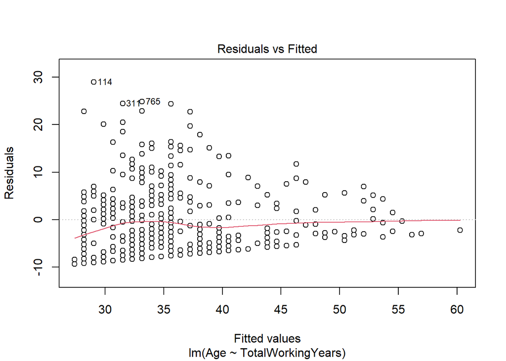

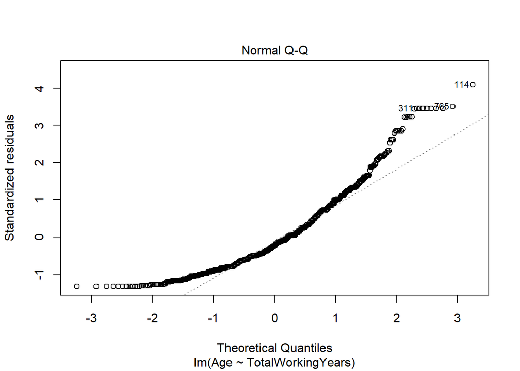

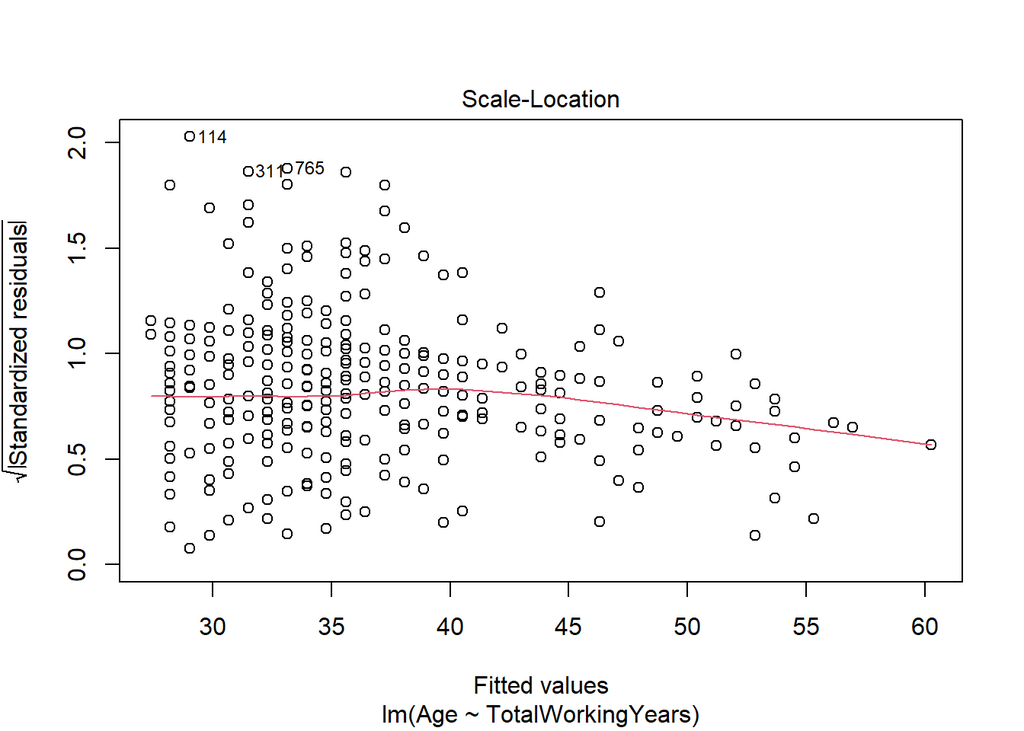

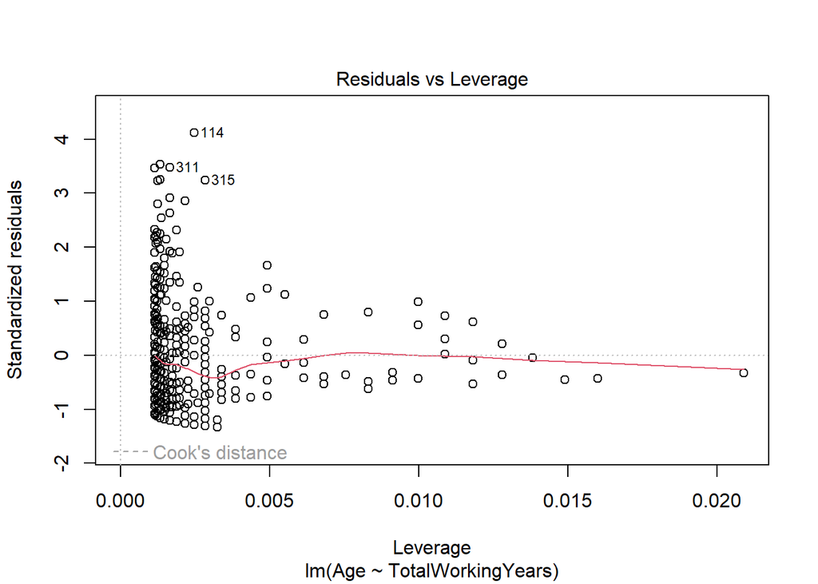

```r
plot(fit)
```

[figure not shown]

```r
# Scatter plot
data_balanced_both %>% ggplot(aes(Age, TotalWorkingYears, color = Attrition)) +
  geom_jitter() +
  ylab("Age") + xlab("Total Working Years") +
  ggtitle("Age vs. Total Working Years")
```

```r
# Model 2.lm, Controlling for Job Involvement
fit = lm(Age ~ TotalWorkingYears + JobInvolvement, data = data_balanced_both)
summary(fit)
```

```
##
## Call:
## lm(formula = Age ~ TotalWorkingYears + JobInvolvement, data = data_balanced_both)
##
## Residuals:
##     Min      1Q  Median      3Q     Max
## -10.164  -5.046  -1.629   3.723  28.547
##
## Coefficients:
##                   Estimate Std. Error t value Pr(>|t|)
## (Intercept)        24.6161     0.9061   27.17  < 2e-16 ***
## TotalWorkingYears   0.8242     0.0326   25.28  < 2e-16 ***
## JobInvolvement      1.0627     0.3107    3.42 0.000655 ***
## ---
## Signif. codes:  0 '***' 0.001 '**' 0.01 '*' 0.05 '.' 0.1 ' ' 1
##
## Residual standard error: 7 on 867 degrees of freedom
## Multiple R-squared:  0.4274, Adjusted R-squared:  0.4261
## F-statistic: 323.6 on 2 and 867 DF,  p-value: < 2.2e-16
```

```r
confint(fit)
```

```
##                        2.5 %     97.5 %
## (Intercept)       22.8376089 26.3945735
## TotalWorkingYears  0.7602169  0.8881796
## JobInvolvement     0.4528550  1.6726018
```

```r
# Model 3.lm, Controlling for the Interaction of Total Working Years and Job Involvement
fit = lm(Age ~ TotalWorkingYears*JobInvolvement, data = data_balanced_both)
summary(fit)
```

```
##
## Call:
## lm(formula = Age ~ TotalWorkingYears * JobInvolvement, data = data_balanced_both)
##
## Residuals:
##    Min     1Q Median     3Q    Max
## -9.973 -5.089 -1.570  3.697 28.623
##
## Coefficients:
##                                  Estimate Std. Error t value Pr(>|t|)
## (Intercept)                      25.17819    1.40564  17.912  < 2e-16 ***
## TotalWorkingYears                 0.77021    0.10821   7.118  2.3e-12 ***
## JobInvolvement                    0.84379    0.52126   1.619    0.106
## TotalWorkingYears:JobInvolvement  0.02115    0.04042   0.523    0.601
## ---
## Signif. codes:  0 '***' 0.001 '**' 0.01 '*' 0.05 '.' 0.1 ' ' 1
##
## Residual standard error: 7.003 on 866 degrees of freedom
## Multiple R-squared:  0.4276, Adjusted R-squared:  0.4256
## F-statistic: 215.6 on 3 and 866 DF,  p-value: < 2.2e-16
```

```r
confint(fit)
```

```
##                                        2.5 %     97.5 %
## (Intercept)                      22.41932818 27.9370424
## TotalWorkingYears                 0.55782774  0.9825955
## JobInvolvement                   -0.17928702  1.8668760
## TotalWorkingYears:JobInvolvement -0.05818938  0.1004921
```

```r
# Model 4.lm, Controlling for Job Involvement and Attrition
fit = lm(Age ~ TotalWorkingYears + JobInvolvement + factor(Attrition), data = data_balanced_both)
summary(fit)
```

```
##
## Call:
## lm(formula = Age ~ TotalWorkingYears + JobInvolvement + factor(Attrition),
##     data = data_balanced_both)
##
## Residuals:
##     Min      1Q  Median      3Q     Max
## -10.425  -5.001  -1.646   3.464  28.130
##
## Coefficients:
##                      Estimate Std. Error t value Pr(>|t|)
## (Intercept)           25.4652     1.0422  24.433  < 2e-16 ***
## TotalWorkingYears      0.8145     0.0331  24.608  < 2e-16 ***
## JobInvolvement         0.9254     0.3215   2.879  0.00409 **
## factor(Attrition)Yes  -0.8191     0.4982  -1.644  0.10055
## ---
## Signif. codes:  0 '***' 0.001 '**' 0.01 '*' 0.05 '.' 0.1 ' ' 1
##
## Residual standard error: 6.993 on 866 degrees of freedom
## Multiple R-squared:  0.4292, Adjusted R-squared:  0.4272
## F-statistic:   217 on 3 and 866 DF,  p-value: < 2.2e-16
```

```r
confint(fit)
```

```
##                           2.5 %     97.5 %
## (Intercept)          23.4195985 27.5107845
## TotalWorkingYears     0.7495198  0.8794452
## JobInvolvement        0.2944092  1.5563295
## factor(Attrition)Yes -1.7969912  0.1588077
```

```r
# Model 5.lm, Controlling for Interaction of Job Involvement and Attrition
fit = lm(Age ~ TotalWorkingYears + JobInvolvement*factor(Attrition), data = data_balanced_both)
summary(fit)
```

```
##
## Call:
## lm(formula = Age ~ TotalWorkingYears + JobInvolvement * factor(Attrition),
##     data = data_balanced_both)
##
## Residuals:
##     Min      1Q  Median      3Q     Max
## -10.071  -4.863  -1.402   3.480  28.297
##
## Coefficients:
##                                     Estimate Std. Error t value Pr(>|t|)
## (Intercept)                         27.43079    1.49313  18.371   <2e-16 ***
## TotalWorkingYears                    0.81581    0.03306  24.676   <2e-16 ***
## JobInvolvement                       0.21337    0.50344   0.424   0.6718
## factor(Attrition)Yes                -3.96073    1.78201  -2.223   0.0265 *
## JobInvolvement:factor(Attrition)Yes  1.19812    0.65258   1.836   0.0667 .
## ---
## Signif. codes:  0 '***' 0.001 '**' 0.01 '*' 0.05 '.' 0.1 ' ' 1
##
## Residual standard error: 6.984 on 865 degrees of freedom
## Multiple R-squared:  0.4314, Adjusted R-squared:  0.4288
## F-statistic: 164.1 on 4 and 865 DF,  p-value: < 2.2e-16
```

```r
confint(fit)
```

```
##                                          2.5 %     97.5 %
## (Intercept)                         24.5002036 30.3613726
## TotalWorkingYears                    0.7509249  0.8807043
## JobInvolvement                      -0.7747423  1.2014787
## factor(Attrition)Yes                -7.4583049 -0.4631613
## JobInvolvement:factor(Attrition)Yes -0.0826922  2.4789421
```

```r
# Model 6.lm, Controlling for Job Involvement, Stock Option Level, and Attrition
fit = lm(Age ~ TotalWorkingYears + JobInvolvement + StockOptionLevel + factor(Attrition), data = data_balanced_both)
summary(fit)
```

```
##
## Call:
## lm(formula = Age ~ TotalWorkingYears + JobInvolvement + StockOptionLevel +
##     factor(Attrition), data = data_balanced_both)
##
## Residuals:
##     Min      1Q  Median      3Q     Max
## -10.460  -4.861  -1.565   3.535  27.642
##
## Coefficients:
##                      Estimate Std. Error t value Pr(>|t|)
## (Intercept)          25.28811    1.04821  24.125  < 2e-16 ***
## TotalWorkingYears     0.81295    0.03309  24.567  < 2e-16 ***
## JobInvolvement        0.87939    0.32272   2.725  0.00656 **
## StockOptionLevel      0.40274    0.26947   1.495  0.13540
## factor(Attrition)Yes -0.73153    0.50132  -1.459  0.14487
## ---
## Signif. codes:  0 '***' 0.001 '**' 0.01 '*' 0.05 '.' 0.1 ' ' 1
##
## Residual standard error: 6.988 on 865 degrees of freedom
## Multiple R-squared:  0.4307, Adjusted R-squared:  0.428
## F-statistic: 163.6 on 4 and 865 DF,  p-value: < 2.2e-16
```

```r
confint(fit)
```

```
##                           2.5 %     97.5 %
## (Intercept)          23.2307803 27.3454338
## TotalWorkingYears     0.7480011  0.8778967
## JobInvolvement        0.2459961  1.5127893
## StockOptionLevel     -0.1261542  0.9316274
## factor(Attrition)Yes -1.7154792  0.2524152
```

```r
# Model 7.lm, Controlling for Job Involvement, and the interaction between Stock Option Level and Attrition
fit = lm(Age ~ TotalWorkingYears + JobInvolvement + StockOptionLevel*factor(Attrition), data = data_balanced_both)
summary(fit)
```

```
##
## Call:
## lm(formula = Age ~ TotalWorkingYears + JobInvolvement + StockOptionLevel *
##     factor(Attrition), data = data_balanced_both)
##
## Residuals:
##     Min      1Q  Median      3Q     Max
## -10.729  -4.966  -1.476   3.657  28.600
##
## Coefficients:
##                                       Estimate Std. Error t value Pr(>|t|)
## (Intercept)                            26.1505     1.0802  24.209  < 2e-16 ***
## TotalWorkingYears                       0.8028     0.0331  24.258  < 2e-16 ***
## JobInvolvement                          0.8594     0.3212   2.675  0.00761 **
## StockOptionLevel                       -0.4673     0.3899  -1.198  0.23106
## factor(Attrition)Yes                   -1.8722     0.6218  -3.011  0.00268 **
## StockOptionLevel:factor(Attrition)Yes   1.6517     0.5373   3.074  0.00218 **
## ---
## Signif. codes:  0 '***' 0.001 '**' 0.01 '*' 0.05 '.' 0.1 ' ' 1
##
## Residual standard error: 6.954 on 864 degrees of freedom
## Multiple R-squared:  0.4368, Adjusted R-squared:  0.4336
## F-statistic:   134 on 5 and 864 DF,  p-value: < 2.2e-16
```

```r
confint(fit)
```

```
##                                            2.5 %     97.5 %
## (Intercept)                           24.0304081 28.2706401
## TotalWorkingYears                      0.7378571  0.8677696
## JobInvolvement                         0.2289209  1.4898335
## StockOptionLevel                      -1.2325327  0.2979757
## factor(Attrition)Yes                  -3.0925270 -0.6518428
## StockOptionLevel:factor(Attrition)Yes  0.5970854  2.7063673
```

Time to test our classification models on our correlated variables

```r
# Split our data into a train and test set
# k = 3 for all models
set.seed(8)
splitPerc = .8
trainIndices = sample(1:dim(data_balanced_both)[1],round(splitPerc * dim(data_balanced_both)[1]))
dftrain = data_balanced_both[trainIndices,]
dftest = data_balanced_both[-trainIndices,]

# Model 1.knn, Age and Total Working Years
classifications = knn(dftrain[,c(2,30)],dftest[,c(2,30)],dftrain$Attrition,
                      prob = TRUE, k = 3)
table(classifications,dftest$Attrition)
```

```
##
## classifications No Yes
##             No  55  18
##             Yes 35  66
```

```r
confusionMatrix(table(classifications,dftest$Attrition))
```

```
## Confusion Matrix and Statistics
##
##
## classifications No Yes
##             No  55  18
##             Yes 35  66
##
##                Accuracy : 0.6954
##                  95% CI : (0.6212, 0.7628)
##     No Information Rate : 0.5172
##     P-Value [Acc > NIR] : 1.341e-06
##
##                   Kappa : 0.3942
##
##  Mcnemar's Test P-Value : 0.02797
##
##             Sensitivity : 0.6111
##             Specificity : 0.7857
##          Pos Pred Value : 0.7534
##          Neg Pred Value : 0.6535
##              Prevalence : 0.5172
##          Detection Rate : 0.3161
##    Detection Prevalence : 0.4195
##       Balanced Accuracy : 0.6984
##
##        'Positive' Class : No
##
```

```r
# Model 1.cv,Internal CV
classifications = knn.cv(data_balanced_both[,c(2,30)],data_balanced_both$Attrition,prob = TRUE, k = 3)
confusionMatrix(table(classifications,data_balanced_both$Attrition))
```

```
## Confusion Matrix and Statistics
##
##
## classifications  No Yes
##             No  296  80
##             Yes 152 342
##
##                Accuracy : 0.7333
##                  95% CI : (0.7026, 0.7625)
##     No Information Rate : 0.5149
##     P-Value [Acc > NIR] : < 2.2e-16
##
##                   Kappa : 0.4688
##
##  Mcnemar's Test P-Value : 3.141e-06
##
##             Sensitivity : 0.6607
##             Specificity : 0.8104
##          Pos Pred Value : 0.7872
##          Neg Pred Value : 0.6923
##              Prevalence : 0.5149
##          Detection Rate : 0.3402
##    Detection Prevalence : 0.4322
##       Balanced Accuracy : 0.7356
##
##        'Positive' Class : No
##
```

```r
# Model 1.nb, Naive Bayes
model = naiveBayes(train[,c(2,30)],train$Attrition)
  table(predict(model,test[,c(2,30)]),test$Attrition)
```

```
##
##        No Yes
##   No  145  28
##   Yes   0   1
```

```r
  CM = confusionMatrix(table(predict(model,test[,c(2,30)]),test$Attrition))
  CM
```

```
## Confusion Matrix and Statistics
##
##
##        No Yes
##   No  145  28
##   Yes   0   1
##
##                Accuracy : 0.8391
##                  95% CI : (0.7759, 0.8903)
##     No Information Rate : 0.8333
##     P-Value [Acc > NIR] : 0.4685
##
##                   Kappa : 0.0562
##
##  Mcnemar's Test P-Value : 3.352e-07
##
##             Sensitivity : 1.00000
##             Specificity : 0.03448
##          Pos Pred Value : 0.83815
##          Neg Pred Value : 1.00000
##              Prevalence : 0.83333
##          Detection Rate : 0.83333
##    Detection Prevalence : 0.99425
##       Balanced Accuracy : 0.51724
##
##        'Positive' Class : No
##
```

```r
# Model 2.knn, Columns = Age, Job Involvement, Total Working Years
classifications = knn(dftrain[,c(2,15,30)],dftest[,c(2,15,30)],dftrain$Attrition,
                      prob = TRUE, k = 3)
table(classifications,dftest$Attrition)
```

```
##
## classifications No Yes
##             No  58  14
##             Yes 32  70
```

```r
confusionMatrix(table(classifications,dftest$Attrition))
```

```
## Confusion Matrix and Statistics
##
##
## classifications No Yes
##             No  58  14
##             Yes 32  70
##
##                Accuracy : 0.7356
##                  95% CI : (0.6636, 0.7995)
##     No Information Rate : 0.5172
##     P-Value [Acc > NIR] : 3.09e-09
##
##                   Kappa : 0.4744
##
##  Mcnemar's Test P-Value : 0.01219
##
##             Sensitivity : 0.6444
##             Specificity : 0.8333
##          Pos Pred Value : 0.8056
##          Neg Pred Value : 0.6863
##              Prevalence : 0.5172
##          Detection Rate : 0.3333
##    Detection Prevalence : 0.4138
##       Balanced Accuracy : 0.7389
##
##        'Positive' Class : No
##
```

```r
# Model 2.cv, Internal CV
classifications = knn.cv(data_balanced_both[,c(2,15,30)],data_balanced_both$Attrition,prob = TRUE, k = 3)
confusionMatrix(table(classifications,data_balanced_both$Attrition))
```

```
## Confusion Matrix and Statistics
##
##
## classifications  No Yes
##             No  300  78
##             Yes 148 344
##
##                Accuracy : 0.7402
##                  95% CI : (0.7097, 0.7691)
##     No Information Rate : 0.5149
##     P-Value [Acc > NIR] : < 2.2e-16
##
##                   Kappa : 0.4825
##
##  Mcnemar's Test P-Value : 4.436e-06
##
##             Sensitivity : 0.6696
##             Specificity : 0.8152
##          Pos Pred Value : 0.7937
##          Neg Pred Value : 0.6992
##              Prevalence : 0.5149
##          Detection Rate : 0.3448
##    Detection Prevalence : 0.4345
##       Balanced Accuracy : 0.7424
##
##        'Positive' Class : No
##
```

```r
# Model 2.nb, Naive Bayes
model = naiveBayes(train[,c(2,15,30)],train$Attrition)
  table(predict(model,test[,c(2,15,30)]),test$Attrition)
```

```
##
##        No Yes
##   No  145  23
##   Yes   0   6
```

```r
  CM = confusionMatrix(table(predict(model,test[,c(2,15,30)]),test$Attrition))
  CM
```

```
## Confusion Matrix and Statistics
##
##
##        No Yes
##   No  145  23
##   Yes   0   6
##
##                Accuracy : 0.8678
##                  95% CI : (0.8083, 0.9143)
##     No Information Rate : 0.8333
##     P-Value [Acc > NIR] : 0.1301
##
##                   Kappa : 0.303
##
##  Mcnemar's Test P-Value : 4.49e-06
##
##             Sensitivity : 1.0000
##             Specificity : 0.2069
##          Pos Pred Value : 0.8631
##          Neg Pred Value : 1.0000
##              Prevalence : 0.8333
##          Detection Rate : 0.8333
##    Detection Prevalence : 0.9655
##       Balanced Accuracy : 0.6034
##
##        'Positive' Class : No
##
```

```r
# Model 3.knn, Columns = Age, Job Involvement, Stock Option Level, Total Working Years
classifications = knn(dftrain[,c(2,15,29,30)],dftest[,c(2,15,29,30)],dftrain$Attrition,
                      prob = TRUE, k = 3)
table(classifications,dftest$Attrition)
```

```
##
## classifications No Yes
##             No  63  13
##             Yes 27  71
```

```r
confusionMatrix(table(classifications,dftest$Attrition))
```

```
## Confusion Matrix and Statistics
##
##
## classifications No Yes
##             No  63  13
##             Yes 27  71
##
##                Accuracy : 0.7701
##                  95% CI : (0.7004, 0.8304)
##     No Information Rate : 0.5172
##     P-Value [Acc > NIR] : 5.544e-12
##
##                   Kappa : 0.5422
##
##  Mcnemar's Test P-Value : 0.03983
##
##             Sensitivity : 0.7000
##             Specificity : 0.8452
##          Pos Pred Value : 0.8289
##          Neg Pred Value : 0.7245
##              Prevalence : 0.5172
##          Detection Rate : 0.3621
##    Detection Prevalence : 0.4368
##       Balanced Accuracy : 0.7726
##
##        'Positive' Class : No
##
```

```r
# Model 3.cv, Internal CV
classifications = knn.cv(data_balanced_both[,c(2,15,29,30)],data_balanced_both$Attrition,prob = TRUE, k = 3)
confusionMatrix(table(classifications,data_balanced_both$Attrition))
```

```
## Confusion Matrix and Statistics
##
##
## classifications  No Yes
##             No  304  58
##             Yes 144 364
##
##                Accuracy : 0.7678
##                  95% CI : (0.7383, 0.7955)
##     No Information Rate : 0.5149
##     P-Value [Acc > NIR] : < 2.2e-16
##
##                   Kappa : 0.5379
##
##  Mcnemar's Test P-Value : 2.223e-09
##
##             Sensitivity : 0.6786
##             Specificity : 0.8626
##          Pos Pred Value : 0.8398
##          Neg Pred Value : 0.7165
##              Prevalence : 0.5149
##          Detection Rate : 0.3494
##    Detection Prevalence : 0.4161
##       Balanced Accuracy : 0.7706
##
##        'Positive' Class : No
##
```

```r
# Model 3.nb, Naive Bayes
model = naiveBayes(train[,c(2,15,29,30)],train$Attrition)
  table(predict(model,test[,c(2,15,29,30)]),test$Attrition)
```

```
##
##        No Yes
##   No  144  23
##   Yes   1   6
```

```r
  CM = confusionMatrix(table(predict(model,test[,c(2,15,30)]),test$Attrition))
  CM
```

```
## Confusion Matrix and Statistics
##
##
##        No Yes
##   No  145  23
##   Yes   0   6
##
##                Accuracy : 0.8678
##                  95% CI : (0.8083, 0.9143)
##     No Information Rate : 0.8333
##     P-Value [Acc > NIR] : 0.1301
##
##                   Kappa : 0.303
##
##  Mcnemar's Test P-Value : 4.49e-06
##
##             Sensitivity : 1.0000
##             Specificity : 0.2069
##          Pos Pred Value : 0.8631
##          Neg Pred Value : 1.0000
##              Prevalence : 0.8333
##          Detection Rate : 0.8333
##    Detection Prevalence : 0.9655
##       Balanced Accuracy : 0.6034
##
##        'Positive' Class : No
##
```

Now let’s switch gears to predict Monthly Incomes

```r
# Model 8.lm, Co linearity of Monthly Income and Total Working Years, Raw data
fit = lm(MonthlyIncome ~ TotalWorkingYears, data = data_balanced_both)
summary(fit)
```

```
##
## Call:
## lm(formula = MonthlyIncome ~ TotalWorkingYears, data = data_balanced_both)
##
## Residuals:
##     Min      1Q  Median      3Q     Max
## -9034.7 -1502.0  -112.1  1167.8 11046.9
##
## Coefficients:
##                   Estimate Std. Error t value Pr(>|t|)
## (Intercept)        1318.81     152.63   8.641   <2e-16 ***
## TotalWorkingYears   450.70      12.48  36.110   <2e-16 ***
## ---
## Signif. codes:  0 '***' 0.001 '**' 0.01 '*' 0.05 '.' 0.1 ' ' 1
##
## Residual standard error: 2681 on 868 degrees of freedom
## Multiple R-squared:  0.6004, Adjusted R-squared:  0.5999
## F-statistic:  1304 on 1 and 868 DF,  p-value: < 2.2e-16
```

```r
confint(fit)
```

```
##                       2.5 %    97.5 %
## (Intercept)       1019.2447 1618.3723
## TotalWorkingYears  426.2003  475.1935
```

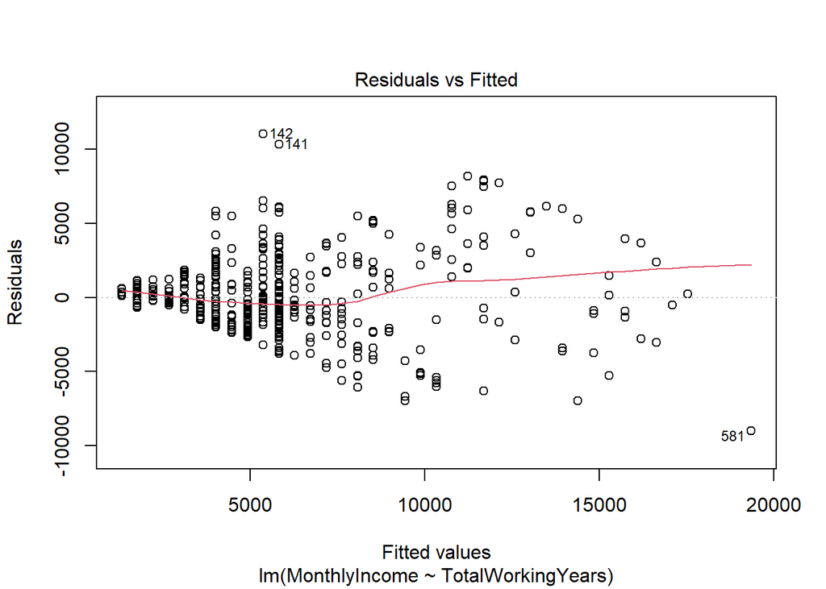

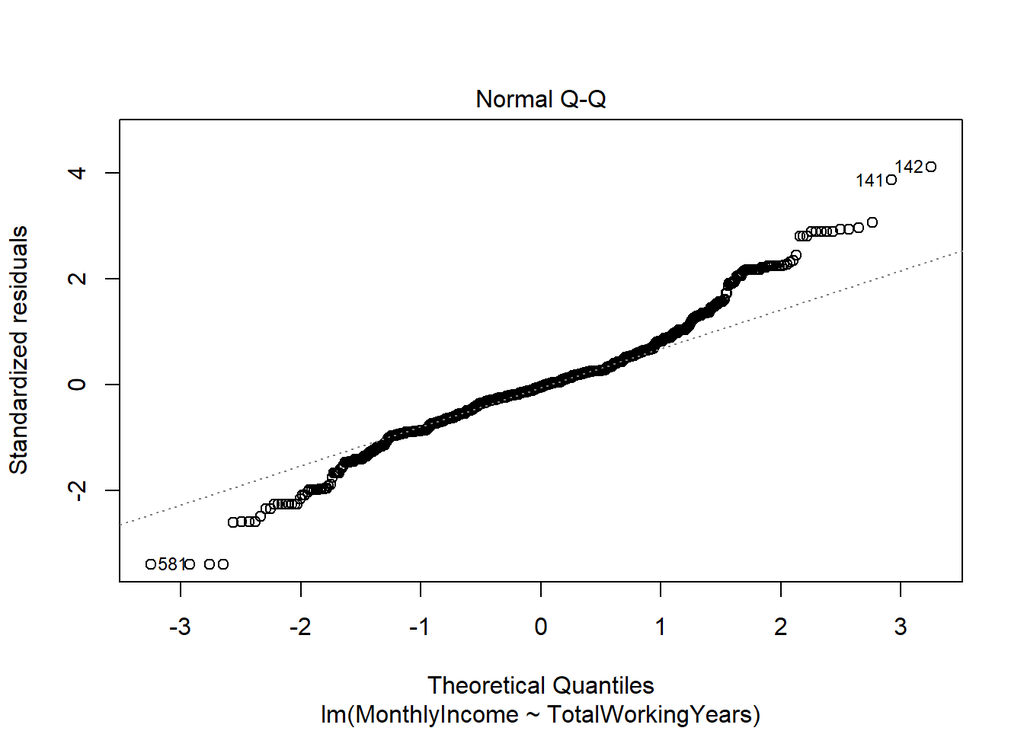

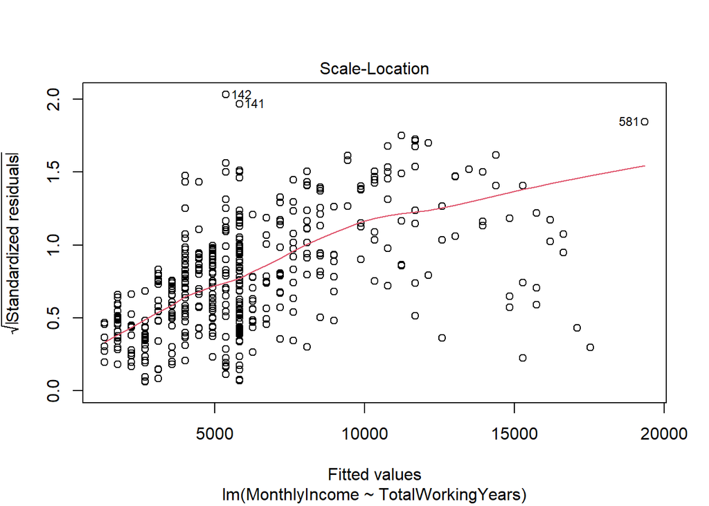

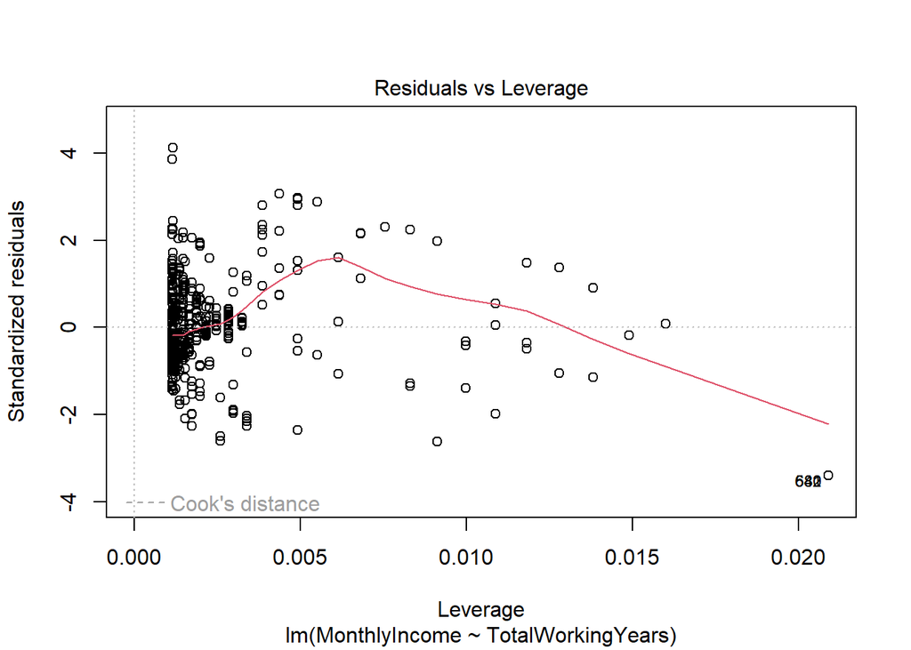

```r
plot(fit)
```

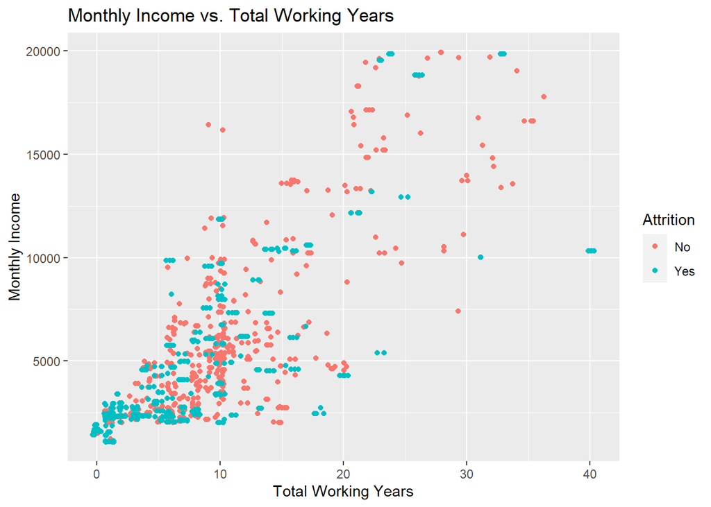

```r
# Scatterplot, raw data
data_balanced_both %>%
  ggplot(aes(TotalWorkingYears, MonthlyIncome, color = Attrition)) +
  geom_jitter() +
  ylab("Monthly Income") + xlab("Total Working Years") +
  ggtitle("Monthly Income vs. Total Working Years")
```

```r
# Log-transform the monthly income data:
data_balanced_both$log_Income = log(data_balanced_both$MonthlyIncome)

# Model 9.lm, Co linearity of Monthly Income and Total Working Years, log-transformed data
fit = lm(log_Income ~ TotalWorkingYears, data = data_balanced_both)
summary(fit)
```

```
##
## Call:
## lm(formula = log_Income ~ TotalWorkingYears, data = data_balanced_both)
##
## Residuals:
##      Min       1Q   Median       3Q      Max
## -1.23896 -0.30044 -0.01609  0.31439  1.33194
##
## Coefficients:
##                   Estimate Std. Error t value Pr(>|t|)
## (Intercept)        7.76314    0.02470  314.30   <2e-16 ***
## TotalWorkingYears  0.06792    0.00202   33.63   <2e-16 ***
## ---
## Signif. codes:  0 '***' 0.001 '**' 0.01 '*' 0.05 '.' 0.1 ' ' 1
##
## Residual standard error: 0.4338 on 868 degrees of freedom
## Multiple R-squared:  0.5658, Adjusted R-squared:  0.5653
## F-statistic:  1131 on 1 and 868 DF,  p-value: < 2.2e-16
```

```r
confint(fit)
```

```
##                        2.5 %     97.5 %
## (Intercept)       7.71465793 7.81161450
## TotalWorkingYears 0.06395797 0.07188651
```

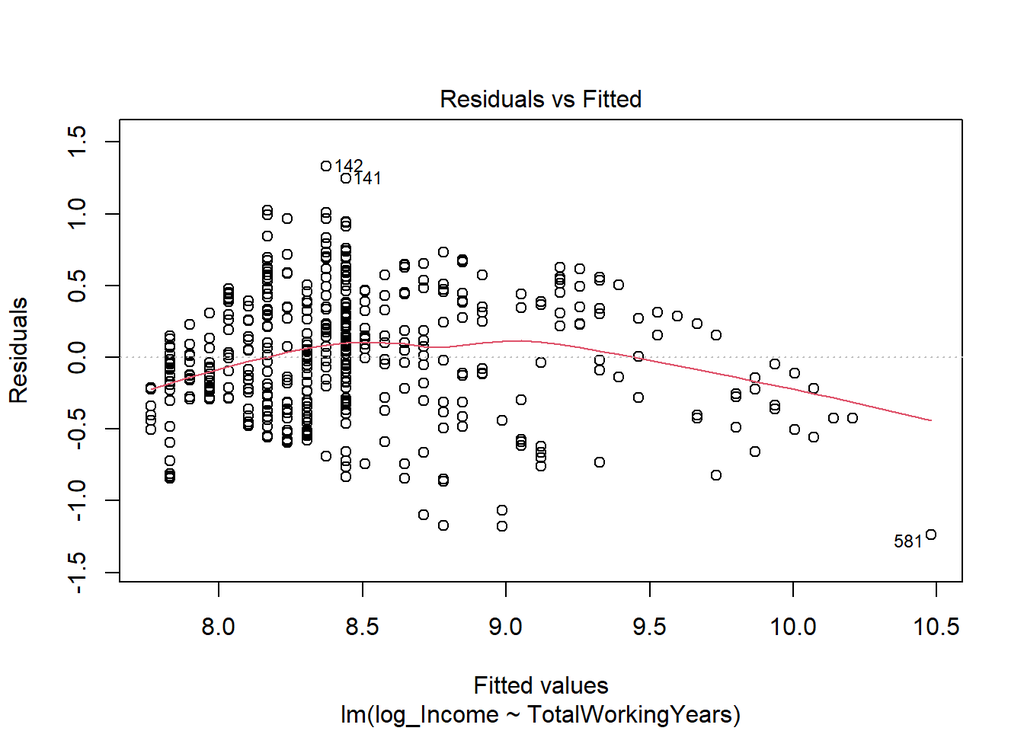

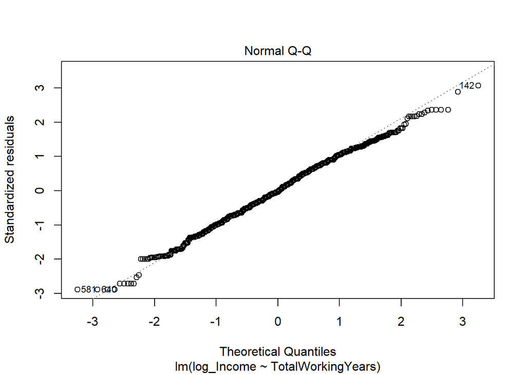

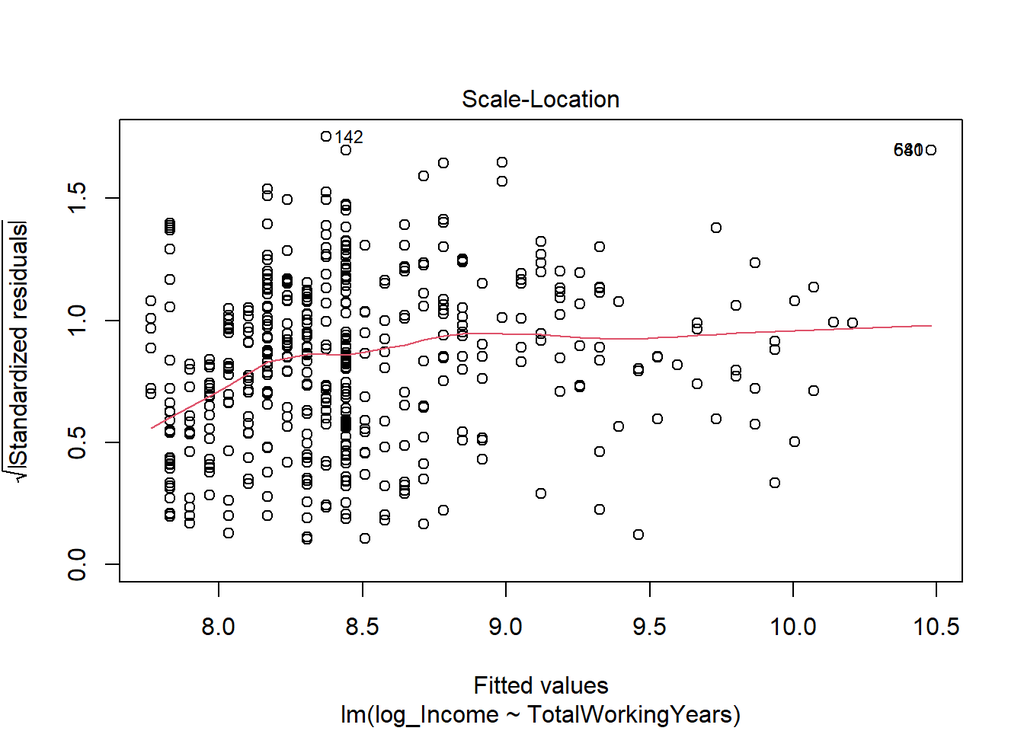

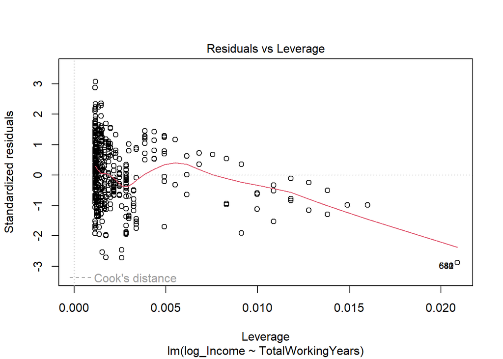

```r
plot(fit)
```

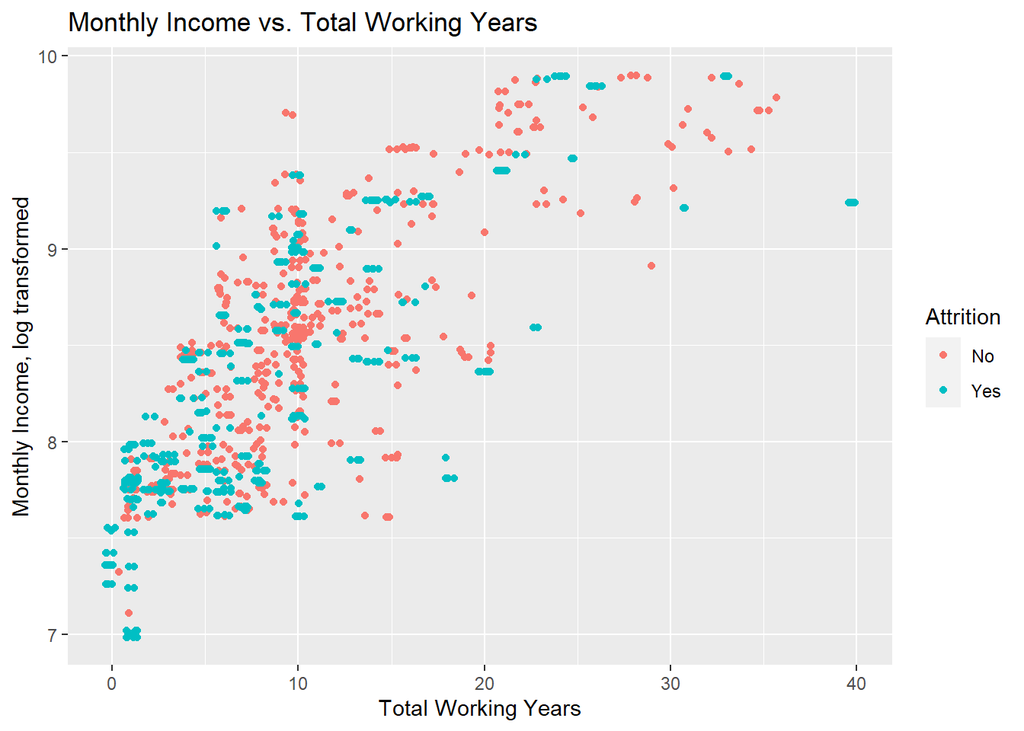

```r
# Scatterplot, log-linear model
data_balanced_both %>%
  ggplot(aes(TotalWorkingYears, log_Income, color = Attrition)) +
  geom_jitter() +
  ylab("Monthly Income, log transformed") + xlab("Total Working Years") +
  ggtitle("Monthly Income vs. Total Working Years")
```

```r
# Model 10.lm, Controlling for Age
fit = lm(log_Income ~ TotalWorkingYears + Age, data = data_balanced_both)
summary(fit)
```

```
##
## Call:
## lm(formula = log_Income ~ TotalWorkingYears + Age, data = data_balanced_both)
##
## Residuals:
##      Min       1Q   Median       3Q      Max
## -1.23499 -0.29007 -0.00746  0.32038  1.33861
##
## Coefficients:
##                   Estimate Std. Error t value Pr(>|t|)
## (Intercept)       7.714973   0.062395 123.646   <2e-16 ***
## TotalWorkingYears 0.066478   0.002652  25.069   <2e-16 ***
## Age               0.001758   0.002091   0.841    0.401
## ---
## Signif. codes:  0 '***' 0.001 '**' 0.01 '*' 0.05 '.' 0.1 ' ' 1
##
## Residual standard error: 0.4339 on 867 degrees of freedom
## Multiple R-squared:  0.5661, Adjusted R-squared:  0.5651
## F-statistic: 565.6 on 2 and 867 DF,  p-value: < 2.2e-16
```

```r
confint(fit)
```

```
##                          2.5 %      97.5 %
## (Intercept)        7.592509622 7.837437337
## TotalWorkingYears  0.061273360 0.071682968
## Age               -0.002346541 0.005862154
```

```r
# Model 11.lm, Controlling for the Interaction of Total Working Years and Age
fit = lm(log_Income ~ TotalWorkingYears*Age, data = data_balanced_both)
summary(fit)
```

```
##
## Call:
## lm(formula = log_Income ~ TotalWorkingYears * Age, data = data_balanced_both)
##
## Residuals:
##      Min       1Q   Median       3Q      Max
## -1.29128 -0.25864  0.03991  0.29283  1.27818
##
## Coefficients:
##                         Estimate Std. Error t value Pr(>|t|)
## (Intercept)            7.2796177  0.0824392  88.303  < 2e-16 ***
## TotalWorkingYears      0.1293392  0.0085023  15.212  < 2e-16 ***
## Age                    0.0121291  0.0024254   5.001 6.91e-07 ***
## TotalWorkingYears:Age -0.0014031  0.0001809  -7.755 2.48e-14 ***
## ---
## Signif. codes:  0 '***' 0.001 '**' 0.01 '*' 0.05 '.' 0.1 ' ' 1
##
## Residual standard error: 0.4198 on 866 degrees of freedom
## Multiple R-squared:  0.5943, Adjusted R-squared:  0.5929
## F-statistic: 422.8 on 3 and 866 DF,  p-value: < 2.2e-16
```

```r
confint(fit)
```

```
##                              2.5 %       97.5 %
## (Intercept)            7.117813816  7.441421634
## TotalWorkingYears      0.112651612  0.146026818
## Age                    0.007368806  0.016889316
## TotalWorkingYears:Age -0.001758258 -0.001048014
```

```r
# Model 12.lm, Controlling for the Interaction of Total Working Years and Age, and Attrition
fit = lm(log_Income ~ TotalWorkingYears*Age + Attrition, data = data_balanced_both)
summary(fit)
```

```
##
## Call:
## lm(formula = log_Income ~ TotalWorkingYears * Age + Attrition,
##     data = data_balanced_both)
##
## Residuals:
##      Min       1Q   Median       3Q      Max
## -1.31979 -0.27342  0.03442  0.30169  1.24134
##
## Coefficients:
##                         Estimate Std. Error t value Pr(>|t|)
## (Intercept)            7.3588229  0.0874768  84.123  < 2e-16 ***
## TotalWorkingYears      0.1258082  0.0085784  14.666  < 2e-16 ***
## Age                    0.0111808  0.0024437   4.575 5.45e-06 ***
## AttritionYes          -0.0769259  0.0291751  -2.637  0.00852 **
## TotalWorkingYears:Age -0.0013357  0.0001821  -7.334 5.13e-13 ***
## ---
## Signif. codes:  0 '***' 0.001 '**' 0.01 '*' 0.05 '.' 0.1 ' ' 1
##
## Residual standard error: 0.4184 on 865 degrees of freedom
## Multiple R-squared:  0.5975, Adjusted R-squared:  0.5957
## F-statistic:   321 on 4 and 865 DF,  p-value: < 2.2e-16
```

```r
confint(fit)
```

```
##                              2.5 %        97.5 %
## (Intercept)            7.187131187  7.5305145826
## TotalWorkingYears      0.108971171  0.1426451824
## Age                    0.006384604  0.0159770282
## AttritionYes          -0.134188198 -0.0196635287
## TotalWorkingYears:Age -0.001693161 -0.0009782623
```

```r
# Model 13.lm, Controlling for the Interaction of Total Working Years and Age, and Interaction of Job Involvement and Attrition
fit = lm(log_Income ~ TotalWorkingYears*Age +
           JobInvolvement*factor(Attrition), data = data_balanced_both)
summary(fit)
```

```
##
## Call:
## lm(formula = log_Income ~ TotalWorkingYears * Age + JobInvolvement *
##     factor(Attrition), data = data_balanced_both)
##
## Residuals:
##      Min       1Q   Median       3Q      Max
## -1.31776 -0.27077  0.03651  0.29840  1.24159
##
## Coefficients:
##                                       Estimate Std. Error t value Pr(>|t|)
## (Intercept)                          7.3430322  0.1208827  60.745  < 2e-16 ***
## TotalWorkingYears                    0.1245432  0.0086471  14.403  < 2e-16 ***
## Age                                  0.0113053  0.0024472   4.620 4.43e-06 ***
## JobInvolvement                       0.0058418  0.0301750   0.194    0.847
## factor(Attrition)Yes                 0.0108739  0.1071156   0.102    0.919
## TotalWorkingYears:Age               -0.0013158  0.0001829  -7.193 1.37e-12 ***
## JobInvolvement:factor(Attrition)Yes -0.0359110  0.0392602  -0.915    0.361
## ---
## Signif. codes:  0 '***' 0.001 '**' 0.01 '*' 0.05 '.' 0.1 ' ' 1
##
## Residual standard error: 0.4185 on 863 degrees of freedom
## Multiple R-squared:  0.5982, Adjusted R-squared:  0.5954
## F-statistic: 214.1 on 6 and 863 DF,  p-value: < 2.2e-16
```

```r
confint(fit)
```

```
##                                            2.5 %        97.5 %
## (Intercept)                          7.105773644  7.5802907576
## TotalWorkingYears                    0.107571341  0.1415151175
## Age                                  0.006502183  0.0161084056
## JobInvolvement                      -0.053383249  0.0650667872
## factor(Attrition)Yes                -0.199363589  0.2211113836
## TotalWorkingYears:Age               -0.001674870 -0.0009568088
## JobInvolvement:factor(Attrition)Yes -0.112967634  0.0411455961
```

```r
# Model 14.lm, Controlling for the Interaction of Total Working Years and Age, and Stock Option Level
fit = lm(log_Income ~ TotalWorkingYears*Age +
           StockOptionLevel, data = data_balanced_both)
summary(fit)
```

```
##
## Call:
## lm(formula = log_Income ~ TotalWorkingYears * Age + StockOptionLevel,
##     data = data_balanced_both)
##
## Residuals:
##      Min       1Q   Median       3Q      Max
## -1.27982 -0.27363  0.03894  0.29528  1.28869
##
## Coefficients:
##                         Estimate Std. Error t value Pr(>|t|)
## (Intercept)            7.2762156  0.0825068  88.189  < 2e-16 ***
## TotalWorkingYears      0.1290066  0.0085086  15.162  < 2e-16 ***
## Age                    0.0119251  0.0024337   4.900 1.14e-06 ***
## StockOptionLevel       0.0161705  0.0159992   1.011    0.312
## TotalWorkingYears:Age -0.0013952  0.0001811  -7.704 3.61e-14 ***
## ---
## Signif. codes:  0 '***' 0.001 '**' 0.01 '*' 0.05 '.' 0.1 ' ' 1
##
## Residual standard error: 0.4198 on 865 degrees of freedom
## Multiple R-squared:  0.5948, Adjusted R-squared:  0.5929
## F-statistic: 317.4 on 4 and 865 DF,  p-value: < 2.2e-16
```

```r
confint(fit)
```

```
##                              2.5 %       97.5 %
## (Intercept)            7.114278609  7.438152575
## TotalWorkingYears      0.112306637  0.145706479
## Age                    0.007148436  0.016701744
## StockOptionLevel      -0.015231262  0.047572325
## TotalWorkingYears:Age -0.001750664 -0.001039761
```

```r
# Model 15.lm, Controlling for the Interaction of Total Working Years and Age, and Attrition
fit = lm(log_Income ~ TotalWorkingYears*Age +
           factor(Attrition), data = data_balanced_both)
summary(fit)
```

```
##
## Call:
## lm(formula = log_Income ~ TotalWorkingYears * Age + factor(Attrition),
##     data = data_balanced_both)
##
## Residuals:
##      Min       1Q   Median       3Q      Max
## -1.31979 -0.27342  0.03442  0.30169  1.24134
##
## Coefficients:
##                         Estimate Std. Error t value Pr(>|t|)
## (Intercept)            7.3588229  0.0874768  84.123  < 2e-16 ***
## TotalWorkingYears      0.1258082  0.0085784  14.666  < 2e-16 ***
## Age                    0.0111808  0.0024437   4.575 5.45e-06 ***
## factor(Attrition)Yes  -0.0769259  0.0291751  -2.637  0.00852 **
## TotalWorkingYears:Age -0.0013357  0.0001821  -7.334 5.13e-13 ***
## ---
## Signif. codes:  0 '***' 0.001 '**' 0.01 '*' 0.05 '.' 0.1 ' ' 1
##
## Residual standard error: 0.4184 on 865 degrees of freedom
## Multiple R-squared:  0.5975, Adjusted R-squared:  0.5957
## F-statistic:   321 on 4 and 865 DF,  p-value: < 2.2e-16
```

```r
confint(fit)
```

```
##                              2.5 %        97.5 %
## (Intercept)            7.187131187  7.5305145826
## TotalWorkingYears      0.108971171  0.1426451824
## Age                    0.006384604  0.0159770282
## factor(Attrition)Yes  -0.134188198 -0.0196635287
## TotalWorkingYears:Age -0.001693161 -0.0009782623
```

```r
# Model 16.lm, Controlling for the Interaction of Total Working Years and Age, Attrition, and interaction of Job Involvement and Attrition
fit = lm(log_Income ~ TotalWorkingYears*Age + factor(Attrition) +
           JobInvolvement*factor(Attrition), data = data_balanced_both)
summary(fit)
```

```
##
## Call:
## lm(formula = log_Income ~ TotalWorkingYears * Age + factor(Attrition) +
##     JobInvolvement * factor(Attrition), data = data_balanced_both)
##
## Residuals:
##      Min       1Q   Median       3Q      Max
## -1.31776 -0.27077  0.03651  0.29840  1.24159
##
## Coefficients:
##                                       Estimate Std. Error t value Pr(>|t|)
## (Intercept)                          7.3430322  0.1208827  60.745  < 2e-16 ***
## TotalWorkingYears                    0.1245432  0.0086471  14.403  < 2e-16 ***
## Age                                  0.0113053  0.0024472   4.620 4.43e-06 ***
## factor(Attrition)Yes                 0.0108739  0.1071156   0.102    0.919
## JobInvolvement                       0.0058418  0.0301750   0.194    0.847
## TotalWorkingYears:Age               -0.0013158  0.0001829  -7.193 1.37e-12 ***
## factor(Attrition)Yes:JobInvolvement -0.0359110  0.0392602  -0.915    0.361
## ---
## Signif. codes:  0 '***' 0.001 '**' 0.01 '*' 0.05 '.' 0.1 ' ' 1
##
## Residual standard error: 0.4185 on 863 degrees of freedom
## Multiple R-squared:  0.5982, Adjusted R-squared:  0.5954
## F-statistic: 214.1 on 6 and 863 DF,  p-value: < 2.2e-16
```

```r
confint(fit)
```

```
##                                            2.5 %        97.5 %
## (Intercept)                          7.105773644  7.5802907576
## TotalWorkingYears                    0.107571341  0.1415151175
## Age                                  0.006502183  0.0161084056
## factor(Attrition)Yes                -0.199363589  0.2211113836
## JobInvolvement                      -0.053383249  0.0650667872
## TotalWorkingYears:Age               -0.001674870 -0.0009568088
## factor(Attrition)Yes:JobInvolvement -0.112967634  0.0411455961
```

```r
# Model 17.lm, Controlling for the Interaction of Total Working Years, Attrition, and Gender
fit = lm(log_Income ~ TotalWorkingYears*Age + factor(Attrition) +
           Gender, data = data_balanced_both)
summary(fit)
```

```
##
## Call:
## lm(formula = log_Income ~ TotalWorkingYears * Age + factor(Attrition) +
##     Gender, data = data_balanced_both)
##
## Residuals:
##      Min       1Q   Median       3Q      Max
## -1.29957 -0.27159  0.01318  0.30355  1.20344
##
## Coefficients:
##                         Estimate Std. Error t value Pr(>|t|)
## (Intercept)            7.3846780  0.0883290  83.604  < 2e-16 ***
## TotalWorkingYears      0.1268238  0.0085802  14.781  < 2e-16 ***
## Age                    0.0115570  0.0024473   4.722 2.72e-06 ***
## factor(Attrition)Yes  -0.0773422  0.0291284  -2.655  0.00807 **
## GenderMale            -0.0578981  0.0296003  -1.956  0.05079 .
## TotalWorkingYears:Age -0.0013671  0.0001825  -7.490 1.70e-13 ***
## ---
## Signif. codes:  0 '***' 0.001 '**' 0.01 '*' 0.05 '.' 0.1 ' ' 1
##
## Residual standard error: 0.4177 on 864 degrees of freedom
## Multiple R-squared:  0.5993, Adjusted R-squared:  0.597
## F-statistic: 258.4 on 5 and 864 DF,  p-value: < 2.2e-16
```

```r
confint(fit)
```

```
##                              2.5 %        97.5 %
## (Intercept)            7.211313548  7.5580424390
## TotalWorkingYears      0.109983296  0.1436642132
## Age                    0.006753750  0.0163602716
## factor(Attrition)Yes  -0.134512820 -0.0201715296
## GenderMale            -0.115995052  0.0001988513
## TotalWorkingYears:Age -0.001725355 -0.0010088455
```

```r
# Model 18.lm, Controlling for the Interaction of Total Working Years and Age, Attrition, Job Involvement, and Stock Option Level
fit = lm(log_Income ~ TotalWorkingYears*Age + Attrition +
           JobInvolvement + StockOptionLevel, data = data_balanced_both)
summary(fit)
```

```
##
## Call:
## lm(formula = log_Income ~ TotalWorkingYears * Age + Attrition +
##     JobInvolvement + StockOptionLevel, data = data_balanced_both)
##
## Residuals:
##      Min       1Q   Median       3Q      Max
## -1.30460 -0.27908  0.03481  0.29993  1.25499
##
## Coefficients:
##                         Estimate Std. Error t value Pr(>|t|)
## (Intercept)            7.3994453  0.1027568  72.009  < 2e-16 ***
## TotalWorkingYears      0.1249765  0.0086266  14.487  < 2e-16 ***
## Age                    0.0111592  0.0024515   4.552 6.07e-06 ***
## AttritionYes          -0.0806952  0.0304026  -2.654   0.0081 **
## JobInvolvement        -0.0166388  0.0194597  -0.855   0.3928
## StockOptionLevel       0.0119323  0.0161698   0.738   0.4608
## TotalWorkingYears:Age -0.0013221  0.0001827  -7.237 1.02e-12 ***
## ---
## Signif. codes:  0 '***' 0.001 '**' 0.01 '*' 0.05 '.' 0.1 ' ' 1
##
## Residual standard error: 0.4186 on 863 degrees of freedom
## Multiple R-squared:  0.5981, Adjusted R-squared:  0.5953
## F-statistic:   214 on 6 and 863 DF,  p-value: < 2.2e-16
```

```r
confint(fit)
```

```
##                              2.5 %        97.5 %
## (Intercept)            7.197762758  7.6011277859
## TotalWorkingYears      0.108044877  0.1419081752
## Age                    0.006347701  0.0159707985
## AttritionYes          -0.140366843 -0.0210236476
## JobInvolvement        -0.054832715  0.0215550407
## StockOptionLevel      -0.019804476  0.0436690136
## TotalWorkingYears:Age -0.001680666 -0.0009635253
```

```r
set.seed(8)
splitPerc = .8
trainIndices = sample(1:dim(data_balanced_both)[1],round(splitPerc * dim(data_balanced_both)[1]))
dftrain = data_balanced_both[trainIndices,]
dftest = data_balanced_both[-trainIndices,]

# Model 16.knn, Columns = Age, Job Involvement, Total Working Years, Monthly Income
classifications = knn(dftrain[,c(2,15,30,38)],dftest[,c(2,15,30,38)],
                      dftrain$Attrition, prob = TRUE, k = 3)
table(classifications,dftest$Attrition)
```

```
##
## classifications No Yes
##             No  57   8
##             Yes 33  76
```

```r
confusionMatrix(table(classifications,dftest$Attrition))
```

```
## Confusion Matrix and Statistics
##
##
## classifications No Yes
##             No  57   8
##             Yes 33  76
##
##                Accuracy : 0.7644
##                  95% CI : (0.6942, 0.8253)
##     No Information Rate : 0.5172
##     P-Value [Acc > NIR] : 1.716e-11
##
##                   Kappa : 0.5328
##
##  Mcnemar's Test P-Value : 0.0001781
##
##             Sensitivity : 0.6333
##             Specificity : 0.9048
##          Pos Pred Value : 0.8769
##          Neg Pred Value : 0.6972
##              Prevalence : 0.5172
##          Detection Rate : 0.3276
##    Detection Prevalence : 0.3736
##       Balanced Accuracy : 0.7690
##
##        'Positive' Class : No
##
```

```r
# Model 16.cv, Internal CV
classifications = knn.cv(data_balanced_both[,c(2,15,30,38)],data_balanced_both$Attrition,prob = TRUE, k = 3)
confusionMatrix(table(classifications,data_balanced_both$Attrition))
```

```
## Confusion Matrix and Statistics
##
##
## classifications  No Yes
##             No  304  56
##             Yes 144 366
##
##                Accuracy : 0.7701
##                  95% CI : (0.7407, 0.7977)
##     No Information Rate : 0.5149
##     P-Value [Acc > NIR] : < 2.2e-16
##
##                   Kappa : 0.5426
##
##  Mcnemar's Test P-Value : 7.659e-10
##
##             Sensitivity : 0.6786
##             Specificity : 0.8673
##          Pos Pred Value : 0.8444
##          Neg Pred Value : 0.7176
##              Prevalence : 0.5149
##          Detection Rate : 0.3494
##    Detection Prevalence : 0.4138
##       Balanced Accuracy : 0.7729
##
##        'Positive' Class : No
##
```

```r
# Model 18.knn, Columns = Age, Job Involvement, Stock Option Level, Total Working Years, Monthly Income
classifications = knn(dftrain[,c(2,15,29,30,38)],dftest[,c(2,15,29,30,38)],
                      dftrain$Attrition, prob = TRUE, k = 3)
table(classifications,dftest$Attrition)
```

```
##
## classifications No Yes
##             No  60   8
##             Yes 30  76
```

```r
confusionMatrix(table(classifications,dftest$Attrition))
```

```
## Confusion Matrix and Statistics
##
##
## classifications No Yes
##             No  60   8
##             Yes 30  76
##
##                Accuracy : 0.7816
##                  95% CI : (0.7128, 0.8406)
##     No Information Rate : 0.5172
##     P-Value [Acc > NIR] : 5.257e-13
##
##                   Kappa : 0.5665
##
##  Mcnemar's Test P-Value : 0.0006577
##
##             Sensitivity : 0.6667
##             Specificity : 0.9048
##          Pos Pred Value : 0.8824
##          Neg Pred Value : 0.7170
##              Prevalence : 0.5172
##          Detection Rate : 0.3448
##    Detection Prevalence : 0.3908
##       Balanced Accuracy : 0.7857
##
##        'Positive' Class : No
##
```

```r
# Model 18.cv, Internal CV
classifications = knn.cv(data_balanced_both[,c(2,15,29,30,38)],data_balanced_both$Attrition,prob = TRUE, k = 3)
confusionMatrix(table(classifications,data_balanced_both$Attrition))
```

```
## Confusion Matrix and Statistics
##
##
## classifications  No Yes
##             No  294  47
##             Yes 154 375
##
##                Accuracy : 0.769
##                  95% CI : (0.7395, 0.7966)
##     No Information Rate : 0.5149
##     P-Value [Acc > NIR] : < 2.2e-16
##
##                   Kappa : 0.5409
##
##  Mcnemar's Test P-Value : 7.623e-14
##
##             Sensitivity : 0.6562
##             Specificity : 0.8886
##          Pos Pred Value : 0.8622
##          Neg Pred Value : 0.7089
##              Prevalence : 0.5149
##          Detection Rate : 0.3379
##    Detection Prevalence : 0.3920
##       Balanced Accuracy : 0.7724
##
##        'Positive' Class : No
##
```

```r
set.seed(12)
TrainObs = sample(seq(1,dim(data_balanced_both)[1]),round(.75*dim(data_balanced_both)[1]),replace = FALSE)
incomeTrain = data_balanced_both[TrainObs,]
incomeTest = data_balanced_both[-TrainObs,]

# Model 11 Fit
Model11_fit = lm(MonthlyIncome ~ TotalWorkingYears*Age, data = incomeTrain)
summary(Model11_fit)
```

```
##
## Call:
## lm(formula = MonthlyIncome ~ TotalWorkingYears * Age, data = incomeTrain)
##
## Residuals:
##     Min      1Q  Median      3Q     Max
## -8143.3 -1550.0   -99.6  1110.8 11130.5
##
## Coefficients:
##                        Estimate Std. Error t value Pr(>|t|)
## (Intercept)           1353.8522   615.3106   2.200   0.0281 *
## TotalWorkingYears      441.7745    61.9884   7.127 2.75e-12 ***
## Age                      1.2544    18.4111   0.068   0.9457
## TotalWorkingYears:Age   -0.2769     1.3011  -0.213   0.8316
## ---
## Signif. codes:  0 '***' 0.001 '**' 0.01 '*' 0.05 '.' 0.1 ' ' 1
##
## Residual standard error: 2714 on 648 degrees of freedom
## Multiple R-squared:  0.5795, Adjusted R-squared:  0.5775
## F-statistic: 297.6 on 3 and 648 DF,  p-value: < 2.2e-16
```

```r
Model11_Preds = predict(Model11_fit, newdata = incomeTest)
as.data.frame(Model11_Preds)
```

```
##     Model11_Preds
## 4       10864.922
## 5        5720.115
## 6        8311.107
## 11       5717.087
## 14      10013.748
## 15       6547.615
## 23       5288.991
## 26      14660.464
## 27       5717.087
## 33       7452.182
## 37       5694.374
## 39       7881.921
## 40      16368.868
## 41       4852.511
```

[output cut: 204 more lines]

```r
MSPE = data.frame(Observed = incomeTest$MonthlyIncome, Predicted = Model11_Preds)
MSPE$Residual = MSPE$Observed - MSPE$Predicted
MSPE$SquaredResidual = MSPE$Residual^2
sqrt(mean(MSPE$SquaredResidual))
```

```
## [1] 2623.618
```

```r
# Model 12 Fit
Model12_fit = lm(MonthlyIncome ~ TotalWorkingYears*Age + Attrition, data = incomeTrain)
summary(Model12_fit)
```

```
##
## Call:
## lm(formula = MonthlyIncome ~ TotalWorkingYears * Age + Attrition,
##     data = incomeTrain)
##
## Residuals:
##     Min      1Q  Median      3Q     Max
## -8001.7 -1577.0  -173.9  1177.4 10993.0
##
## Coefficients:
##                         Estimate Std. Error t value Pr(>|t|)
## (Intercept)           1646.26545  652.56812   2.523   0.0119 *
## TotalWorkingYears      428.91931   62.69015   6.842 1.81e-11 ***
## Age                     -2.23878   18.58390  -0.120   0.9041
## AttritionYes          -291.87176  218.00006  -1.339   0.1811
## TotalWorkingYears:Age   -0.02914    1.31341  -0.022   0.9823
## ---
## Signif. codes:  0 '***' 0.001 '**' 0.01 '*' 0.05 '.' 0.1 ' ' 1
##
## Residual standard error: 2712 on 647 degrees of freedom
## Multiple R-squared:  0.5806, Adjusted R-squared:  0.578
## F-statistic: 223.9 on 4 and 647 DF,  p-value: < 2.2e-16
```

```r
Model12_Preds = predict(Model12_fit, newdata = incomeTest)
as.data.frame(Model12_Preds)
```

```
##     Model12_Preds
## 4       10958.659
## 5        5849.433
## 6        8414.300
## 11       5844.373
## 14      10108.969
## 15       6658.699
## 23       5424.006
## 26      14776.236
## 27       5844.373
## 33       7563.795
## 37       5806.421
## 39       7989.077
## 40      16485.736
## 41       4986.161
```

[output cut: 204 more lines]

```r
MSPE = data.frame(Observed = incomeTest$MonthlyIncome, Predicted = Model12_Preds)
MSPE$Residual = MSPE$Observed - MSPE$Predicted
MSPE$SquaredResidual = MSPE$Residual^2
sqrt(mean(MSPE$SquaredResidual))
```

```
## [1] 2627.067
```

```r
# Model 14 Fit
Model14_fit = lm(MonthlyIncome ~ TotalWorkingYears*Age +
                   StockOptionLevel, data = incomeTrain)
summary(Model14_fit)
```

```
##
## Call:
## lm(formula = MonthlyIncome ~ TotalWorkingYears * Age + StockOptionLevel,
##     data = incomeTrain)
##
## Residuals:
##     Min      1Q  Median      3Q     Max
## -8167.3 -1571.4  -169.5  1141.3 11180.2
##
## Coefficients:
##                        Estimate Std. Error t value Pr(>|t|)
## (Intercept)           1323.3993   617.6125   2.143   0.0325 *
## TotalWorkingYears      440.5073    62.0528   7.099 3.32e-12 ***
## Age                      0.7710    18.4369   0.042   0.9667
## StockOptionLevel        73.5878   120.1602   0.612   0.5405
## TotalWorkingYears:Age   -0.2512     1.3024  -0.193   0.8471
## ---
## Signif. codes:  0 '***' 0.001 '**' 0.01 '*' 0.05 '.' 0.1 ' ' 1
##
## Residual standard error: 2715 on 647 degrees of freedom
## Multiple R-squared:  0.5797, Adjusted R-squared:  0.5771
## F-statistic: 223.1 on 4 and 647 DF,  p-value: < 2.2e-16
```

```r
Model14_Preds = predict(Model14_fit, newdata = incomeTest)
as.data.frame(Model14_Preds)
```

```
##     Model14_Preds
## 4       10883.705
## 5        5669.292
## 6        8331.440
## 11       5739.399
## 14       9959.207
## 15       6492.856
## 23       5238.814
## 26      14607.336
## 27       5739.399
## 33       7399.909
## 37       5639.702
## 39       7829.132
## 40      16316.120
## 41       5022.405
```

[output cut: 204 more lines]

```r
MSPE = data.frame(Observed = incomeTest$MonthlyIncome, Predicted = Model14_Preds)
MSPE$Residual = MSPE$Observed - MSPE$Predicted
MSPE$SquaredResidual = MSPE$Residual^2
sqrt(mean(MSPE$SquaredResidual))
```

```
## [1] 2626.364
```

```r
# These RMSEs are below $3,000, but let's see if we can go lower by using Job Level as the explanatory variable.

# Model 19 Fit
Model19_fit = lm(MonthlyIncome ~ JobLevel + Age*TotalWorkingYears, data = incomeTrain)
summary(Model19_fit)
```

```
##
## Call:
## lm(formula = MonthlyIncome ~ JobLevel + Age * TotalWorkingYears,
##     data = incomeTrain)
##
## Residuals:
##     Min      1Q  Median      3Q     Max
## -4974.9  -834.4    47.8   658.6  3847.6
##
## Coefficients:
##                         Estimate Std. Error t value Pr(>|t|)
## (Intercept)           -1499.3530   313.7392  -4.779 2.18e-06 ***
## JobLevel               3763.8510    85.1141  44.221  < 2e-16 ***
## Age                       0.8835     9.1869   0.096   0.9234
## TotalWorkingYears       -50.3909    32.8729  -1.533   0.1258
## Age:TotalWorkingYears     1.5220     0.6505   2.340   0.0196 *
## ---
## Signif. codes:  0 '***' 0.001 '**' 0.01 '*' 0.05 '.' 0.1 ' ' 1
##
## Residual standard error: 1354 on 647 degrees of freedom
## Multiple R-squared:  0.8955, Adjusted R-squared:  0.8948
## F-statistic:  1385 on 4 and 647 DF,  p-value: < 2.2e-16
```

```r
Model19_Preds = predict(Model19_fit, newdata = incomeTest)
as.data.frame(Model19_Preds)
```

```
##     Model19_Preds
## 4       13925.269
## 5        6071.965
## 6        6105.346
## 11       6104.172
## 14       2540.957
## 15       2655.487
## 23       6056.025
## 26      14541.431
## 27       9868.023
## 33       9819.055
## 37       6345.727
## 39       6078.753
## 40      14662.535
## 41       6108.428
```

[output cut: 204 more lines]

```r
MSPE = data.frame(Observed = incomeTest$MonthlyIncome, Predicted = Model19_Preds)
MSPE$Residual = MSPE$Observed - MSPE$Predicted
MSPE$SquaredResidual = MSPE$Residual^2
sqrt(mean(MSPE$SquaredResidual))
```

```
## [1] 1336.694
```

```r
# Model 20 Fit
Model20_fit = lm(MonthlyIncome ~ JobLevel + Age + TotalWorkingYears, data = incomeTrain)
summary(Model20_fit)
```

```
##
## Call:
## lm(formula = MonthlyIncome ~ JobLevel + Age + TotalWorkingYears,
##     data = incomeTrain)
##
## Residuals:
##     Min      1Q  Median      3Q     Max
## -4947.6  -797.4    29.3   636.1  3857.1
##
## Coefficients:
##                    Estimate Std. Error t value Pr(>|t|)
## (Intercept)       -1965.718    243.120  -8.085 3.05e-15 ***
## JobLevel           3751.398     85.240  44.010  < 2e-16 ***
## Age                  12.176      7.844   1.552    0.121
## TotalWorkingYears    19.811     13.477   1.470    0.142
## ---
## Signif. codes:  0 '***' 0.001 '**' 0.01 '*' 0.05 '.' 0.1 ' ' 1
##
## Residual standard error: 1359 on 648 degrees of freedom
## Multiple R-squared:  0.8946, Adjusted R-squared:  0.8941
## F-statistic:  1833 on 3 and 648 DF,  p-value: < 2.2e-16
```

```r
Model20_Preds = predict(Model20_fit, newdata = incomeTest)
as.data.frame(Model20_Preds)
```

```
##     Model20_Preds
## 4       13999.291
## 5        6149.181
## 6        6280.221
## 11       6173.534
## 14       2681.123
## 15       2656.580
## 23       6117.194
## 26      14299.349
## 27       9924.932
## 33       9967.644
## 37       6356.180
## 39       6248.234
## 40      14378.592
## 41       6146.089
```

[output cut: 204 more lines]

```r
MSPE = data.frame(Observed = incomeTest$MonthlyIncome, Predicted = Model20_Preds)
MSPE$Residual = MSPE$Observed - MSPE$Predicted
MSPE$SquaredResidual = MSPE$Residual^2
sqrt(mean(MSPE$SquaredResidual))
```

```
## [1] 1349.348
```

We are ready for predictions.

```r
predict_attrition <- read.csv('https://github.com/athibeaux/DS6306/raw/main/CaseStudy2_Thibeaux/CaseStudy2CompSet%20No%20Attrition.csv', header = TRUE, fill= TRUE)
predict_attrition$logIncome <- log(predict_attrition$MonthlyIncome)

predict_income <- read.csv('https://github.com/athibeaux/DS6306/raw/main/CaseStudy2_Thibeaux/CaseStudy2CompSet%20No%20Salary.csv', header = TRUE, fill = TRUE)

Model20_fit = lm(MonthlyIncome ~ JobLevel + Age +
                   TotalWorkingYears, data = data_balanced_both)
summary(Model20_fit)
```

```
##
## Call:
## lm(formula = MonthlyIncome ~ JobLevel + Age + TotalWorkingYears,
##     data = data_balanced_both)
##
## Residuals:
##     Min      1Q  Median      3Q     Max
## -5041.9  -799.8    49.3   630.7  3985.1
##
## Coefficients:
##                    Estimate Std. Error t value Pr(>|t|)
## (Intercept)       -1905.125    205.655  -9.264  < 2e-16 ***
## JobLevel           3640.715     72.290  50.363  < 2e-16 ***
## Age                  10.895      6.532   1.668  0.09569 .
## TotalWorkingYears    38.387     11.687   3.285  0.00106 **
## ---
## Signif. codes:  0 '***' 0.001 '**' 0.01 '*' 0.05 '.' 0.1 ' ' 1
##
## Residual standard error: 1354 on 866 degrees of freedom
## Multiple R-squared:  0.8983, Adjusted R-squared:  0.8979
## F-statistic:  2550 on 3 and 866 DF,  p-value: < 2.2e-16
```

```r
Model20_Preds = predict(Model20_fit, newdata = predict_income)
income_predictions <- as.data.frame(Model20_Preds)

predict_income <- add_predictions(predict_income, Model20_fit, var = "pred", type = NULL)
to_csv_incomepreds <- predict_income %>% select(ID,pred)
write.csv(to_csv_incomepreds,"C:\\Users\\29685907\\Desktop\\Case2PredictionsThibeauxIncome.csv",row.names=TRUE)

# Model 18.knn, Columns = Age, Job Involvement, Stock Option Level, Total Working Years, Monthly Income
classifications = knn(dftrain[,c(2,15,29,30,38)],dftest[,c(2,15,29,30,38)],
                      dftrain$Attrition, prob = TRUE, k = 3)
table(classifications,dftest$Attrition)
```

```
##
## classifications No Yes
##             No  58   8
##             Yes 32  76
```

```r
confusionMatrix(table(classifications,dftest$Attrition))
```

```
## Confusion Matrix and Statistics
##
##
## classifications No Yes
##             No  58   8
##             Yes 32  76
##
##                Accuracy : 0.7701
##                  95% CI : (0.7004, 0.8304)
##     No Information Rate : 0.5172
##     P-Value [Acc > NIR] : 5.544e-12
##
##                   Kappa : 0.544
##
##  Mcnemar's Test P-Value : 0.0002762
##
##             Sensitivity : 0.6444
##             Specificity : 0.9048
##          Pos Pred Value : 0.8788
##          Neg Pred Value : 0.7037
##              Prevalence : 0.5172
##          Detection Rate : 0.3333
##    Detection Prevalence : 0.3793
##       Balanced Accuracy : 0.7746
##
##        'Positive' Class : No
##
```

```r
# Model 18.cv, Internal CV
classifications = knn.cv(data_balanced_both[,c(2,15,29,30,38)],data_balanced_both$Attrition,prob = TRUE, k = 3)
confusionMatrix(table(classifications,data_balanced_both$Attrition))
```

```
## Confusion Matrix and Statistics
##
##
## classifications  No Yes
##             No  296  47
##             Yes 152 375
##
##                Accuracy : 0.7713
##                  95% CI : (0.7419, 0.7988)
##     No Information Rate : 0.5149
##     P-Value [Acc > NIR] : < 2.2e-16
##
##                   Kappa : 0.5454
##
##  Mcnemar's Test P-Value : 1.676e-13
##
##             Sensitivity : 0.6607
##             Specificity : 0.8886
##          Pos Pred Value : 0.8630
##          Neg Pred Value : 0.7116
##              Prevalence : 0.5149
##          Detection Rate : 0.3402
##    Detection Prevalence : 0.3943
##       Balanced Accuracy : 0.7747
##
##        'Positive' Class : No
##
```

```r
# Model 18.knn, Columns = Age, Job Involvement, Stock Option Level, Total Working Years, Monthly Income
classifications = knn(data_balanced_both[,c(2,15,29,30,38)],predict_attrition[,c(2,15,29,30,36)], data_balanced_both$Attrition, prob = TRUE, k = 3)
predict_attrition$preds <- classifications

to_csv_classify <- predict_attrition %>% select(ID,preds)
write.csv(to_csv_classify,"C:\\Users\\29685907\\Desktop\\Case2PredictionsThibeauxAttrition.csv",row.names=TRUE)
```

Job Trends

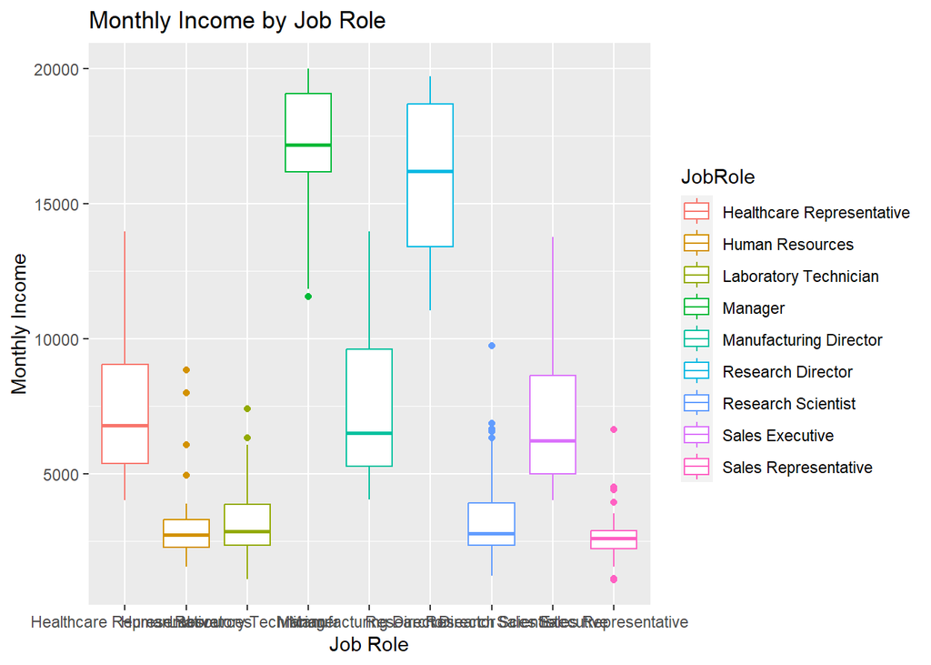

```r
# Income Trends
fritos %>% ggplot(aes(x = JobRole, y = MonthlyIncome, color = JobRole)) +
  geom_boxplot() + xlab("Job Role") + ylab("Monthly Income") +
  ggtitle("Monthly Income by Job Role")
```

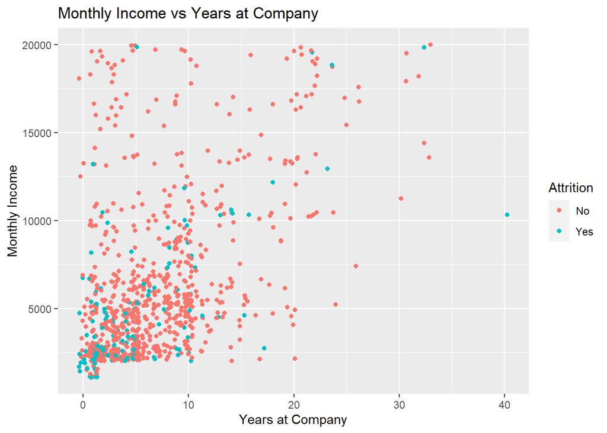

```r
# Linearity of Years at Company and Monthly Income, Legend Attrition
fritos %>% ggplot(aes(x = YearsAtCompany, y = MonthlyIncome, color = Attrition)) +
  geom_jitter() + xlab("Years at Company") + ylab("Monthly Income") +
  ggtitle("Monthly Income vs Years at Company")
```

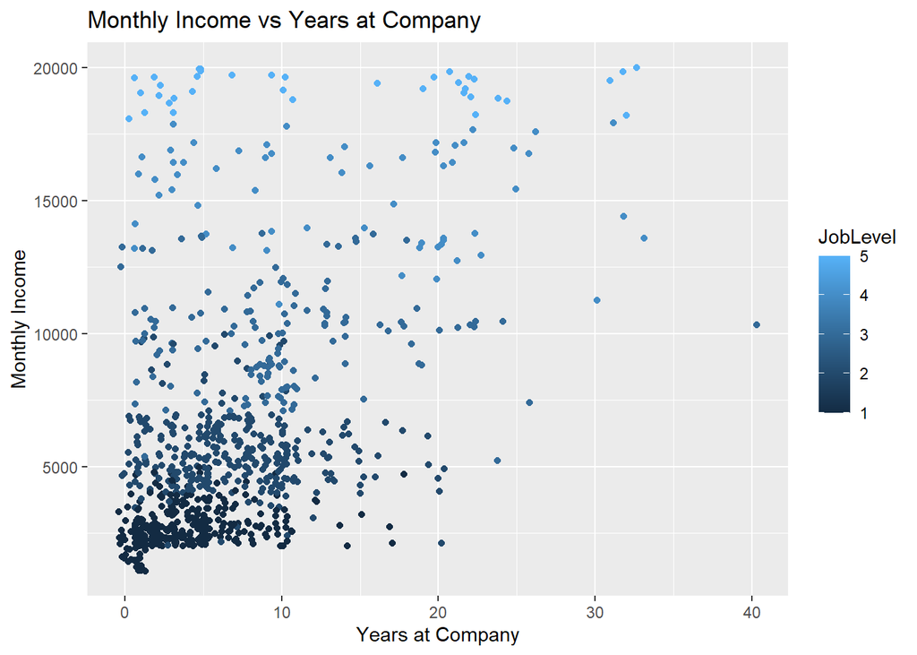

```r
# Linearity of Years at Company and Monthly Income, Legend Job Level
fritos %>% ggplot(aes(x = YearsAtCompany, y = MonthlyIncome, color = JobLevel)) +
  geom_jitter() + xlab("Years at Company") + ylab("Monthly Income") +
  ggtitle("Monthly Income vs Years at Company")
```

```r
# Test Fit for Years At Company and Monthly Income, Controlling for Job Level
fit = lm(MonthlyIncome ~ YearsAtCompany + JobLevel, data = fritos)
summary(fit)
```

```
##
## Call:
## lm(formula = MonthlyIncome ~ YearsAtCompany + JobLevel, data = fritos)
##
## Residuals:
##     Min      1Q  Median      3Q     Max
## -4976.8  -922.8    83.1   699.2  3740.9
##
## Coefficients:
##                Estimate Std. Error t value Pr(>|t|)
## (Intercept)    -1789.30     102.24 -17.501   <2e-16 ***
## YearsAtCompany    -4.22       9.33  -0.452    0.651
## JobLevel        4025.81      51.53  78.120   <2e-16 ***
## ---
## Signif. codes:  0 '***' 0.001 '**' 0.01 '*' 0.05 '.' 0.1 ' ' 1
##
## Residual standard error: 1414 on 867 degrees of freedom
## Multiple R-squared:  0.9056, Adjusted R-squared:  0.9054
## F-statistic:  4161 on 2 and 867 DF,  p-value: < 2.2e-16
```

```r
confint(fit)
```

```
##                      2.5 %     97.5 %
## (Intercept)    -1989.95940 -1588.6327
## YearsAtCompany   -22.53281    14.0919
## JobLevel        3924.66160  4126.9515
```

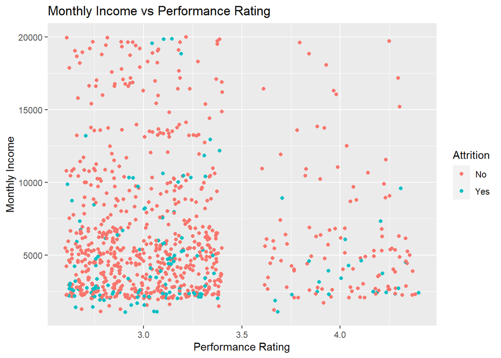

```r
# Linearity of Performance Rating and Monthly Income, Legend Attrition
fritos %>% ggplot(aes(x = PerformanceRating, y = MonthlyIncome, color = Attrition)) +
  geom_jitter() + xlab("Performance Rating") + ylab("Monthly Income") +
  ggtitle("Monthly Income vs Performance Rating")
```

```r
# Test Fit for Performance Rating and Monthly Income, Controlling for Job Level
fit = lm(MonthlyIncome ~ PerformanceRating + JobLevel, data = fritos)
summary(fit)
```

```
##
## Call:
## lm(formula = MonthlyIncome ~ PerformanceRating + JobLevel, data = fritos)
##
## Residuals:
##     Min      1Q  Median      3Q     Max
## -5048.4  -926.3    85.4   698.2  3711.3
##
## Coefficients:
##                   Estimate Std. Error t value Pr(>|t|)
## (Intercept)       -1536.90     436.89  -3.518 0.000458 ***
## PerformanceRating   -80.89     133.71  -0.605 0.545374
## JobLevel           4012.64      44.03  91.137  < 2e-16 ***
## ---
## Signif. codes:  0 '***' 0.001 '**' 0.01 '*' 0.05 '.' 0.1 ' ' 1
##
## Residual standard error: 1414 on 867 degrees of freedom
## Multiple R-squared:  0.9057, Adjusted R-squared:  0.9054
## F-statistic:  4162 on 2 and 867 DF,  p-value: < 2.2e-16
```

```r
confint(fit)
```

```
##                        2.5 %    97.5 %
## (Intercept)       -2394.3933 -679.4069
## PerformanceRating  -343.3185  181.5451
## JobLevel           3926.2253 4099.0560
```

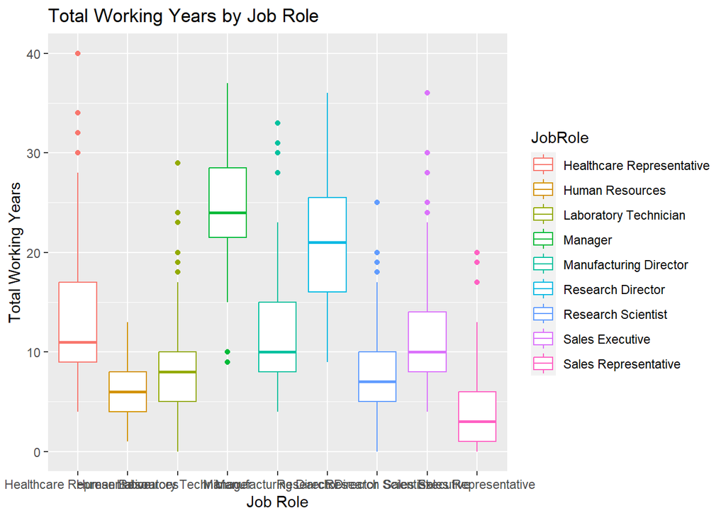

```r
# Total Working Years
fritos %>% ggplot(aes(x = JobRole, y = TotalWorkingYears, color = JobRole)) +
  geom_boxplot() + xlab("Job Role") + ylab("Total Working Years") +
  ggtitle("Total Working Years by Job Role")
```

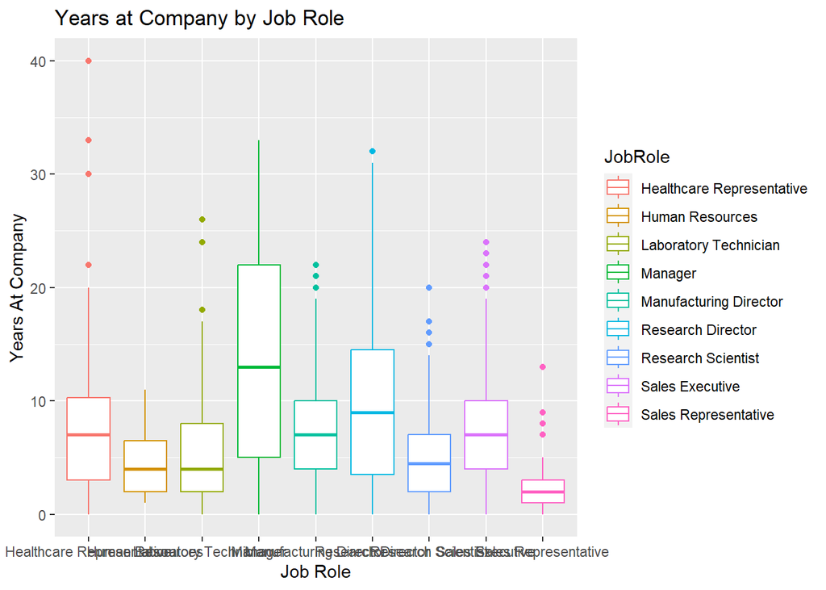

```r
# Years at Company
fritos %>% ggplot(aes(x = JobRole, y = YearsAtCompany, color = JobRole)) +
  geom_boxplot() + xlab("Job Role") + ylab("Years At Company") +
  ggtitle("Years at Company by Job Role")
```

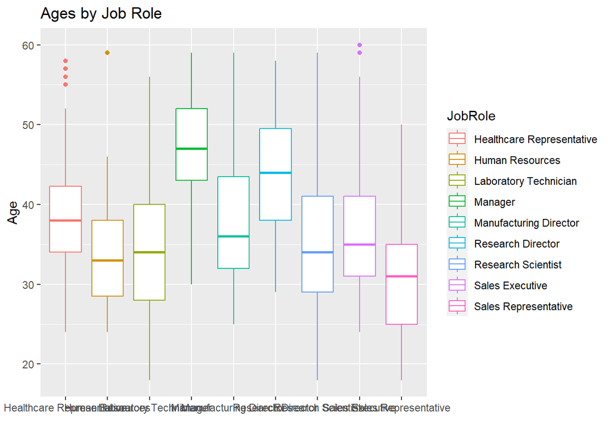

```r
# Age
fritos %>% ggplot(aes(x = JobRole, y = Age, color = JobRole)) +
  geom_boxplot() + xlab("") + ggtitle("Ages by Job Role")
```

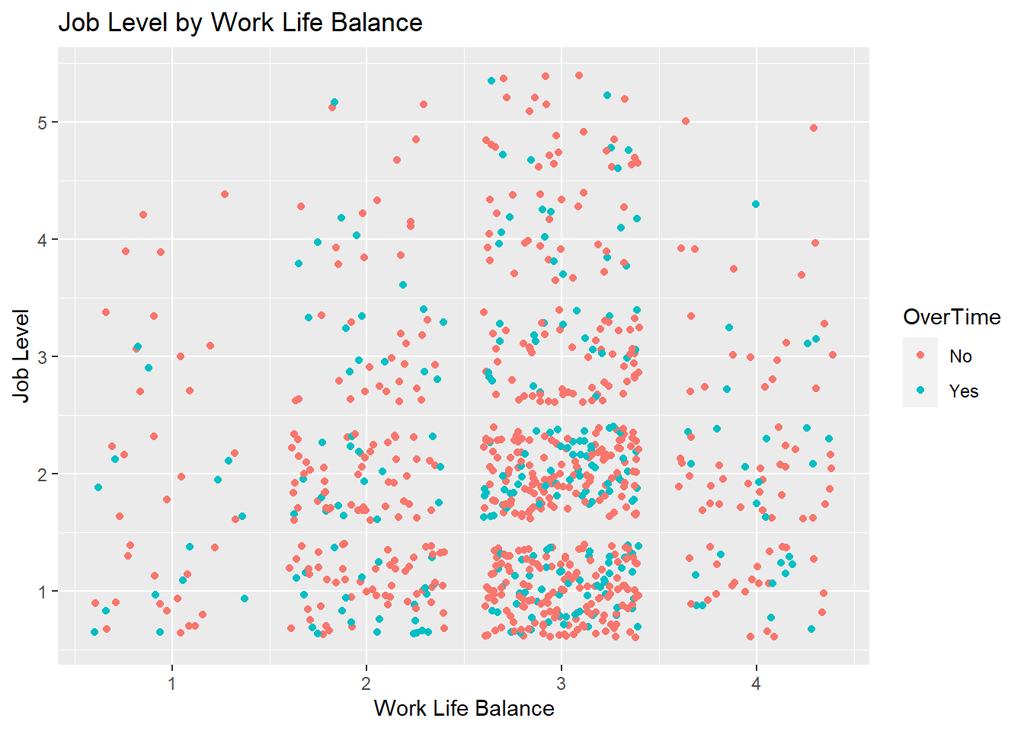

```r
# Work Life Balance, Legend Overtime
fritos %>% ggplot(aes(x = WorkLifeBalance, y = JobLevel, color = OverTime)) +
  geom_jitter() + xlab("Work Life Balance") + ylab("Job Level") +
  ggtitle("Job Level by Work Life Balance")
```